# Housing Price vs. Supply 2024

Stephanie Armstrong, Ilgaz Kuscu, Alexander D. Silberman, Baylee Wechsler

2026-02-23

```r
rm(list=ls())
```

```r
library(ezids)
library(tidyverse)
library(janitor)
library(scales)
library(ggrepel)
library(corrplot)
library(tigris)
library(sf)
library(ggridges)
library(scales)
library(tidycensus)
library(here)
library(car)
library(caTools)
library(glmnet)
library(randomForest)
library(rpart)
library(rpart.plot)
library(rattle)
library(kableExtra)
library(ModelMetrics)
```

## Introduction

In the first project, we examined the relationship between months of supply and median home prices across U.S. metro areas in 2024 using data from the American Enterprise Institute (AEI).

While the analysis identified a clear association between months of supply and median home prices, further exploratory analysis revealed that months of supply is not a raw measure but rather reflects the pace of inventory absorption. This limited our ability to fully understand housing price dynamics and motivated us to seek out new datasets.

The second project uses raw supply measures while incorporating socioeconomic context. The analysis relies on the CBSA-level 2024 Realtor.com dataset as the core housing market dataset. This dataset is enriched with 2024 one-year estimates from the American Community Survey (ACS) to capture demographic, economic, and housing characteristics across U.S. metros.

From the 2024 ACS 1-Year Estimates Data Profiles, we selected variables that provide an overview of population composition, income, and housing characteristics for each CBSA included in the Realtor.com data.

By integrating housing market indicators with structural socioeconomic variables, this project aims to better distinguish whether observed housing price patterns in 2024 are primarily driven by supply constraints, demand-side pressures, or underlying demographic and economic conditions across U.S. metropolitan areas.

## Data

This project uses the CBSA-level 2024 Realtor.com dataset referenced as the source data from our Project 1 data source: the American Enterprise Institute. We enrich this dataset with the 1-year estimate data for 2024 from the American Community Survey (ACS). The variables are:

| Original Variable Name | New Variable Name | Definition |
| --- | --- | --- |
| month_date_yyyymm | month_date_yyyymm | Month/Year date in Realtor.com dataset |
| cbsa_code | cbsa_code | Core-Based Statistical Area (CBSA) code |
| cbsa_title | cbsa_title | CBSA name/title |
| median_listing_price_per_square_foot | median_listing_price_per_square_foot | Median listing price per square foot |
| total_listing_count | total_listing_count | Total number of listings in the CBSA/month |
| pending_ratio | pending_ratio | Share of listings pending sale |
| median_days_on_market | median_days_on_market | Median number of days listings are on the market |
| log_median_price_sqft | log_median_price_sqft | Log of median listing price per square foot |
| DP05_0001E | total_population | Total population (ACS) |
| DP05_0003PE | pct_female | Percent female |
| DP05_0037PE | pct_white | Percent White alone |
| DP05_0045PE | pct_black | Percent Black alone |
| DP05_0053PE | pct_aian | Percent American Indian/Alaska Native |
| DP05_0061PE | pct_asian | Percent Asian alone |
| DP05_0069PE | pct_nhpi | Percent Native Hawaiian/Pacific Islander |
| DP05_0075PE | pct_two_or_more | Percent two or more races |
| DP05_0090PE | pct_hispanic | Percent Hispanic or Latino |
| DP05_0018E | median_age | Median age |
| DP05_0019PE | pct_under_18 | Percent under 18 years old |
| DP02_0001E | total_households | Total households |
| DP02_0002PE | pct_married_couple | Percent married-couple households |
| DP02_0006PE | pct_male_householder | Percent male householder, no spouse |
| DP02_0010PE | pct_female_householder | Percent female householder, no spouse |
| DP03_0005PE | pct_unemployed | Percent unemployed |
| DP03_0119PE | pct_below_poverty | Percent below poverty level |
| DP03_0053PE | pct_income_10_14999 | Percent income $10k–$14,999 |
| DP03_0054PE | pct_income_15_24999 | Percent income $15k–$24,999 |
| DP03_0055PE | pct_income_25_34999 | Percent income $25k–$34,999 |
| DP03_0056PE | pct_income_35_49999 | Percent income $35k–$49,999 |
| DP03_0057PE | pct_income_50_74999 | Percent income $50k–$74,999 |
| DP03_0058PE | pct_income_75_99999 | Percent income $75k–$99,999 |
| DP03_0059PE | pct_income_100_149k | Percent income $100k–$149k |
| DP03_0060PE | pct_income_150_199k | Percent income $150k–$199k |
| DP03_0061PE | pct_income_200k_plus | Percent income $200k+ |
| DP03_0062E | median_household_income | Median household income |
| DP02_0067PE | pct_high_school_plus | Percent high school or higher |
| DP02_0068PE | pct_bachelors_plus | Percent bachelor’s degree or higher |
| DP04_0001E | total_housing_units | Total housing units |
| DP04_0003PE | pct_vacant_units | Percent vacant housing units |
| DP04_0046PE | pct_owner_occupied | Percent owner-occupied housing units |
| DP04_0017PE | pct_built_2020_plus | Percent built 2020+ |
| DP04_0018PE | pct_built_2010_2019 | Percent built 2010–2019 |
| DP04_0019PE | pct_built_2000_2009 | Percent built 2000–2009 |
| DP04_0020PE | pct_built_1990_1999 | Percent built 1990–1999 |
| DP04_0021PE | pct_built_1980_1989 | Percent built 1980–1989 |
| DP04_0022PE | pct_built_1970_1979 | Percent built 1970–1979 |
| DP04_0023PE | pct_built_1960_1969 | Percent built 1960–1969 |
| DP04_0024PE | pct_built_1950_1959 | Percent built 1950–1959 |
| DP04_0025PE | pct_built_1940_1949 | Percent built 1940–1949 |
| DP04_0040PE | pct_1_bed | Percent 1-bedroom units |
| DP04_0041PE | pct_2_bed | Percent 2-bedroom units |
| DP04_0042PE | pct_3_bed | Percent 3-bedroom units |
| DP04_0043PE | pct_4_bed | Percent 4-bedroom units |
| DP04_0044PE | pct_5plus_bed | Percent 5+ bedroom units |

### American Community Survey

From the 2024 ACS 1-Year Estimates Data Profiles (U.S. Census Bureau, 2024), demographic, economic, and housing variables are selected, giving a broad overview of the characteristics of each CBSA in the Realtor.com dataset. Additionally, where necessary, variables have been removed to eliminate multicollinearity.

```r
#ACS variable codes
#use to make a dictionary for the report

#demographics

#DP05_0001E - Total Population

#DP05_0003PE – % Female
#DP05_0037PE – % White alone
#DP05_0045PE – % Black or African American alone
#DP05_0053PE - % American Indian and Alaska Native alone
#DP05_0061PE – % Asian alone
#DP05_0069PE - % Native Hawaiian and Other Pacific Islander alone
#DP05_0075PE - % Two or More Races

#DP05_0090PE – % Hispanic or Latino

#DP05_0018E - Median age (years)
#DP05_0019PE - % Under 18 years

#households

#DP02_0001E – Total households
#DP02_0002PE – % Married-couple households
#DP02_0006PE – % Male householder, no spouse
#DP02_0010PE – % Female householder, no spouse

#economics

#DP03_0005PE – % Unemployed
#DP03_0119PE – % Below poverty level

#DP03_0052PE - % Household income <$10,000 (ELIMINATE FOR MULTICOLLINEARITY)
#DP03_0053PE - % Household income $10,000 to $14,999
#DP03_0054PE - % Household income $15,000 to $24,999
#DP03_0055PE - % Household income $25,000 to $34,999
#DP03_0056PE - % Household income $35,000 to $49,999
#DP03_0057PE - % Household income $50,000 to $74,999
#DP03_0058PE – % Household income $75,000 to $99,999
#DP03_0059PE – % Household income $100,000 to $149,999
#DP03_0060PE – % Household income $150,000 to $199,999
#DP03_0061PE – % Household income $200,000 or more

#DP03_0062E - Median household income (dollars)

#DP02_0067PE - % High school graduate or higher
#DP02_0068PE – % Bachelor’s degree or higher


#housing

#DP04_0001E – Total housing units
#DP04_0003PE – % Vacant units

#DP04_0046PE – % of occupied that are Owner-occupied

#DP04_0017PE - % Units built 2020 or later
#DP04_0018PE - % Units built 2010 to 2019
#DP04_0019PE – % Units built 2000 to 2009
#DP04_0020PE – % Units built 1990 to 1999
#DP04_0021PE – % Units built 1980 to 1989
#DP04_0022PE – % Units built 1970 to 1979
#DP04_0023PE – % Units built 1960 to 1969
#DP04_0024PE – % Units built 1950 to 1959
#DP04_0025PE – % Units built 1940 to 1949
#DP04_0026PE – % Units built 1939 or earlier (ELIMINATE FOR MULTICOLLINEARITY)

#DP04_0039PE - % 0 Bedrooms (ELIMINATE FOR MULTICOLLINEARITY)
#DP04_0040PE - % 1 Bedrooms
#DP04_0041PE - % 2 Bedrooms
#DP04_0042PE - % 3 Bedrooms
#DP04_0043PE - % 4 Bedrooms
#DP04_0044PE - % 5 Bedrooms or more
```

```r
vars_needed <- c("NAME",
                 "GEOID",
                 "DP05_0001E",
                 "DP05_0003PE",
                 "DP05_0037PE",
                 "DP05_0045PE",
                 "DP05_0053PE",
                 "DP05_0061PE",
                 "DP05_0069PE",
                 "DP05_0075PE",
                 "DP05_0090PE",
                 "DP05_0018E",
                 "DP05_0019PE",
                 "DP02_0001E",
                 "DP02_0002PE",
                 "DP02_0006PE",
                 "DP02_0010PE",
                 "DP03_0005PE",
                 "DP03_0119PE",
                 # "DP03_0052PE",
                 "DP03_0053PE",
                 "DP03_0054PE",
                 "DP03_0055PE",
                 "DP03_0056PE",
                 "DP03_0057PE",
                 "DP03_0058PE",
                 "DP03_0059PE",
                 "DP03_0060PE",
                 "DP03_0061PE",
                 "DP03_0062E",
                 "DP02_0067PE",
                 "DP02_0068PE",
                 "DP04_0001E",
                 "DP04_0003PE",
                 "DP04_0046PE",
                 "DP04_0017PE",
                 "DP04_0018PE",
                 "DP04_0019PE",
                 "DP04_0020PE",
                 "DP04_0021PE",
                 "DP04_0022PE",
                 "DP04_0023PE",
                 "DP04_0024PE",
                 "DP04_0025PE",
                 # "DP04_0026PE",
                 # "DP04_0039PE",
                 "DP04_0040PE",
                 "DP04_0041PE",
                 "DP04_0042PE",
                 "DP04_0043PE",
                 "DP04_0044PE")

acs1_2024_orig = get_acs(geography = "metropolitan statistical area/micropolitan statistical area",
                         variables = vars_needed,
                         year = 2024,
                         survey = "acs1",
                         output = "wide")

head(acs1_2024_orig)
```

```
## # A tibble: 6 × 94
##   GEOID NAME           DP05_0001E DP05_0001M DP05_0003PE DP05_0003PM DP05_0037PE
##   <chr> <chr>               <dbl>      <dbl>       <dbl>       <dbl>       <dbl>
## 1 10140 Aberdeen, WA …      77893         NA        49.5         0.8        75.5
## 2 10180 Abilene, TX M…     181969       3181        48.2         0.7        66.7
## 3 10300 Adrian, MI Mi…      97746         NA        50.2         0.6        85.6
## 4 10380 Aguadilla, PR…     250969         NA        51.4         1          52.1
## 5 10420 Akron, OH Met…     702209         NA        51.5         0.2        76
## 6 10460 Alamogordo, N…      69711         NA        47           1.6        53.9
## # ℹ 87 more variables: DP05_0037PM <dbl>, DP05_0045PE <dbl>, DP05_0045PM <dbl>,
## #   DP05_0053PE <dbl>, DP05_0053PM <dbl>, DP05_0061PE <dbl>, DP05_0061PM <dbl>,
## #   DP05_0069PE <dbl>, DP05_0069PM <dbl>, DP05_0075PE <dbl>, DP05_0075PM <dbl>,
## #   DP05_0090PE <dbl>, DP05_0090PM <dbl>, DP05_0018E <dbl>, DP05_0018M <dbl>,
## #   DP05_0019PE <dbl>, DP05_0019PM <dbl>, DP02_0001E <dbl>, DP02_0001M <dbl>,
## #   DP02_0002PE <dbl>, DP02_0002PM <dbl>, DP02_0006PE <dbl>, DP02_0006PM <dbl>,
## #   DP02_0010PE <dbl>, DP02_0010PM <dbl>, DP03_0005PE <dbl>, …
```

```r
acs1_2024_no_M = select(acs1_2024_orig, -grepv("M$", names(acs1_2024_orig)))
head(acs1_2024_no_M)
```

```
## # A tibble: 6 × 48
##   GEOID NAME          DP05_0001E DP05_0003PE DP05_0037PE DP05_0045PE DP05_0053PE
##   <chr> <chr>              <dbl>       <dbl>       <dbl>       <dbl>       <dbl>
## 1 10140 Aberdeen, WA…      77893        49.5        75.5         1.3         4.2
## 2 10180 Abilene, TX …     181969        48.2        66.7         8.5         0.4
## 3 10300 Adrian, MI M…      97746        50.2        85.6         2.4         0.2
## 4 10380 Aguadilla, P…     250969        51.4        52.1         1.2         0
## 5 10420 Akron, OH Me…     702209        51.5        76          12.3         0.2
## 6 10460 Alamogordo, …      69711        47          53.9         4.4         6.5
## # ℹ 41 more variables: DP05_0061PE <dbl>, DP05_0069PE <dbl>, DP05_0075PE <dbl>,
## #   DP05_0090PE <dbl>, DP05_0018E <dbl>, DP05_0019PE <dbl>, DP02_0001E <dbl>,
## #   DP02_0002PE <dbl>, DP02_0006PE <dbl>, DP02_0010PE <dbl>, DP03_0005PE <dbl>,
## #   DP03_0119PE <dbl>, DP03_0053PE <dbl>, DP03_0054PE <dbl>, DP03_0055PE <dbl>,
## #   DP03_0056PE <dbl>, DP03_0057PE <dbl>, DP03_0058PE <dbl>, DP03_0059PE <dbl>,
## #   DP03_0060PE <dbl>, DP03_0061PE <dbl>, DP03_0062E <dbl>, DP02_0067PE <dbl>,
## #   DP02_0068PE <dbl>, DP04_0001E <dbl>, DP04_0003PE <dbl>, …
```

```r
#This includes both percents as well as margins of error. I (Alex) have included code to drop the margins of error.
```

```r
#rename ACS variable codes to real things
acs1_2024 <- acs1_2024_no_M %>%
  rename(total_population = DP05_0001E,
    pct_female = DP05_0003PE,
    pct_white = DP05_0037PE,
    pct_black = DP05_0045PE,
    pct_aian = DP05_0053PE,
    pct_asian = DP05_0061PE,
    pct_nhpi = DP05_0069PE,
    pct_two_or_more = DP05_0075PE,
    pct_hispanic = DP05_0090PE,
    median_age = DP05_0018E,
    pct_under_18 = DP05_0019PE,
    total_households = DP02_0001E,
    pct_married_couple = DP02_0002PE,
    pct_male_householder = DP02_0006PE,
    pct_female_householder = DP02_0010PE,
    pct_unemployed = DP03_0005PE,
    pct_below_poverty = DP03_0119PE,
    # pct_income_lt10k = DP03_0052PE,
    pct_income_10_14999 = DP03_0053PE,
    pct_income_15_24999 = DP03_0054PE,
    pct_income_25_34999 = DP03_0055PE,
    pct_income_35_49999 = DP03_0056PE,
    pct_income_50_74999 = DP03_0057PE,
    pct_income_75_99999 = DP03_0058PE,
    pct_income_100_149k = DP03_0059PE,
    pct_income_150_199k = DP03_0060PE,
    pct_income_200k_plus = DP03_0061PE,
    median_household_income = DP03_0062E,
    pct_high_school_plus = DP02_0067PE,
    pct_bachelors_plus = DP02_0068PE,
    total_housing_units = DP04_0001E,
    pct_vacant_units = DP04_0003PE,
    pct_owner_occupied = DP04_0046PE,
    pct_built_2020_plus = DP04_0017PE,
    pct_built_2010_2019 = DP04_0018PE,
    pct_built_2000_2009 = DP04_0019PE,
    pct_built_1990_1999 = DP04_0020PE,
    pct_built_1980_1989 = DP04_0021PE,
    pct_built_1970_1979 = DP04_0022PE,
    pct_built_1960_1969 = DP04_0023PE,
    pct_built_1950_1959 = DP04_0024PE,
    pct_built_1940_1949 = DP04_0025PE,
    # pct_built_1939_earlier = DP04_0026PE,
    # pct_0_bed = DP04_0039PE,
    pct_1_bed = DP04_0040PE,
    pct_2_bed = DP04_0041PE,
    pct_3_bed = DP04_0042PE,
    pct_4_bed = DP04_0043PE,
    pct_5plus_bed = DP04_0044PE)

# #check it out
head(acs1_2024)
```

```
## # A tibble: 6 × 48
##   GEOID NAME  total_population pct_female pct_white pct_black pct_aian pct_asian
##   <chr> <chr>            <dbl>      <dbl>     <dbl>     <dbl>    <dbl>     <dbl>
## 1 10140 Aber…            77893       49.5      75.5       1.3      4.2       1.6
## 2 10180 Abil…           181969       48.2      66.7       8.5      0.4       2
## 3 10300 Adri…            97746       50.2      85.6       2.4      0.2       0.3
## 4 10380 Agua…           250969       51.4      52.1       1.2      0         0
## 5 10420 Akro…           702209       51.5      76        12.3      0.2       4.3
## 6 10460 Alam…            69711       47        53.9       4.4      6.5       1.5
## # ℹ 40 more variables: pct_nhpi <dbl>, pct_two_or_more <dbl>,
## #   pct_hispanic <dbl>, median_age <dbl>, pct_under_18 <dbl>,
## #   total_households <dbl>, pct_married_couple <dbl>,
## #   pct_male_householder <dbl>, pct_female_householder <dbl>,
## #   pct_unemployed <dbl>, pct_below_poverty <dbl>, pct_income_10_14999 <dbl>,
## #   pct_income_15_24999 <dbl>, pct_income_25_34999 <dbl>,
## #   pct_income_35_49999 <dbl>, pct_income_50_74999 <dbl>, …
```

```r
#I want to make a area type var here before merging
#create area_type var
acs1_2024 <- acs1_2024 %>%
  mutate(area_type = ifelse(grepl("Micro Area",NAME), "Micro", "Metro"))

unique(acs1_2024$area_type)
```

```
## [1] "Micro" "Metro"
```

#### Realtor.com

```r
#loading in inventory data
inventory_raw <- read_csv("../Data/RDC_Inventory_Core_Metrics_Metro_History.csv")

#cleaning names
clean_names(inventory_raw)
```

```
## # A tibble: 103,600 × 47
##    month_date_yyyymm cbsa_code cbsa_title    household_rank median_listing_price
##                <dbl>     <dbl> <chr>                  <dbl>                <dbl>
##  1            202510     35620 New York-New…              1               762450
##  2            202510     31080 Los Angeles-…              2              1099000
##  3            202510     16980 Chicago-Nape…              3               364900
##  4            202510     19100 Dallas-Fort …              4               425000
##  5            202510     26420 Houston-Pasa…              5               358000
##  6            202510     37980 Philadelphia…              6               379973
##  7            202510     33100 Miami-Fort L…              7               499999
##  8            202510     12060 Atlanta-Sand…              8               415000
##  9            202510     47900 Washington-A…              9               594500
## 10            202510     38060 Phoenix-Mesa…             10               495000
## # ℹ 103,590 more rows
## # ℹ 42 more variables: median_listing_price_mm <dbl>,
## #   median_listing_price_yy <dbl>, active_listing_count <dbl>,
## #   active_listing_count_mm <dbl>, active_listing_count_yy <dbl>,
## #   median_days_on_market <dbl>, median_days_on_market_mm <dbl>,
## #   median_days_on_market_yy <dbl>, new_listing_count <dbl>,
## #   new_listing_count_mm <dbl>, new_listing_count_yy <dbl>, …
```

```r
#hunting down year
glimpse(inventory_raw)
```

```
## Rows: 103,600
## Columns: 47
## $ month_date_yyyymm                       <dbl> 202510, 202510, 202510, 202510…
## $ cbsa_code                               <dbl> 35620, 31080, 16980, 19100, 26…
## $ cbsa_title                              <chr> "New York-Newark-Jersey City, …
## $ HouseholdRank                           <dbl> 1, 2, 3, 4, 5, 6, 7, 8, 9, 10,…
## $ median_listing_price                    <dbl> 762450, 1099000, 364900, 42500…
## $ median_listing_price_mm                 <dbl> 0.0039, 0.0000, -0.0200, 0.000…
## $ median_listing_price_yy                 <dbl> -0.0160, -0.0443, -0.0138, -0.…
## $ active_listing_count                    <dbl> 36156, 18409, 16751, 29448, 33…
## $ active_listing_count_mm                 <dbl> 0.0074, -0.0470, -0.0048, -0.0…
## $ active_listing_count_yy                 <dbl> 0.0388, 0.1787, -0.0175, 0.136…
## $ median_days_on_market                   <dbl> 54, 57, 38, 64, 57, 43, 86, 60…
## $ median_days_on_market_mm                <dbl> -0.0609, 0.0000, 0.0133, 0.015…
## $ median_days_on_market_yy                <dbl> 0.0093, 0.1875, 0.0270, 0.1327…
```

[output cut: 34 more lines]

```r
#filtering for 2024
inventory_2024 <- inventory_raw %>%
  filter(month_date_yyyymm >= 202401 & month_date_yyyymm <= 202412)

#filtered for target vars
inventory_2024_filtered <- inventory_2024%>%
  select(
    month_date_yyyymm,
    cbsa_code,
    cbsa_title,
    median_listing_price_per_square_foot,
    total_listing_count,
    pending_ratio,
    median_days_on_market)%>%
  mutate(
    log_median_price_sqft = log(median_listing_price_per_square_foot)) %>%
  drop_na()

summary(inventory_2024_filtered)
```

```
##  month_date_yyyymm   cbsa_code      cbsa_title
##  Min.   :202401    Min.   :10100   Length:11052
##  1st Qu.:202404    1st Qu.:20100   Class :character
##  Median :202407    Median :29860   Mode  :character
##  Mean   :202407    Mean   :29857
##  3rd Qu.:202410    3rd Qu.:39700
##  Max.   :202412    Max.   :49820
##  median_listing_price_per_square_foot total_listing_count pending_ratio
##  Min.   :  48                         Min.   :   17       Min.   :0.002
##  1st Qu.: 134                         1st Qu.:  136       1st Qu.:0.318
##  Median : 169                         Median :  284       Median :0.490
##  Mean   : 202                         Mean   : 1255       Mean   :0.553
##  3rd Qu.: 224                         3rd Qu.:  776       3rd Qu.:0.719
##  Max.   :1708                         Max.   :52936       Max.   :2.679
##  median_days_on_market log_median_price_sqft
##  Min.   :  9.0         Min.   :3.87
##  1st Qu.: 46.0         1st Qu.:4.90
##  Median : 58.0         Median :5.13
##  Mean   : 60.1         Mean   :5.19
##  3rd Qu.: 72.0         3rd Qu.:5.41
##  Max.   :164.0         Max.   :7.44
```

The Realtor.com inventory dataset provides monthly metro-level housing indicators like listing counts, median prices, and days on market. Unlike the ACS, it doesn’t include paired estimates or margins of error. Each variable is already given as a direct point estimate. Some fields (the _mm and _yy columns) represent month-over-month or year-over-year percent changes, which introduce redundancy, so we later drop those before modeling. Aside from that, the data only need to be filtered to the 2024 months and are ready for use.

```r
#cbsa code var to chr so merge works
inventory_2024_filtered <- inventory_2024_filtered %>%
  mutate(cbsa_code = as.character(cbsa_code))

#merge ACS and inventory datasets
full_dataset <- acs1_2024 %>%
  left_join(inventory_2024_filtered, by = c("GEOID" = "cbsa_code"))

#which vars to factor
factor_vars <- c("GEOID",
                 # "NAME",
                 "cbsa_title",
                 # "HouseholdRank",
                 # "quality_flag",
                 "area_type")

#drop redundant columns
redundant_vars <- c("NAME")

#clean dataset
full_dataset_clean <- full_dataset %>%
  select(-all_of(redundant_vars)) %>% # Drop redundant columns
  mutate(across(all_of(factor_vars), as.factor)) #%>% # Convert factor variables
  # mutate(log_median_listing_price = log(median_listing_price)) # Log home price

#NAs by variable type
na_summary_one <- full_dataset_clean %>%
  summarise(across(everything(), ~ sum(is.na(.)))) %>%
  pivot_longer(everything(), names_to = "variable", values_to = "NA_count") %>%
  mutate(var_type = ifelse(variable %in% factor_vars, "factor", "numeric")) %>%
  arrange(desc(NA_count))

print(na_summary_one)
```

```
## # A tibble: 55 × 3
##    variable               NA_count var_type
##    <chr>                     <int> <chr>
##  1 pct_white                    60 numeric
##  2 pct_black                    60 numeric
##  3 pct_aian                     60 numeric
##  4 pct_asian                    60 numeric
##  5 pct_nhpi                     60 numeric
##  6 pct_two_or_more              60 numeric
##  7 total_households              6 numeric
##  8 pct_married_couple            6 numeric
##  9 pct_male_householder          6 numeric
## 10 pct_female_householder        6 numeric
## # ℹ 45 more rows
```

```r
#address NAs (drop hispanic, when organized by FIPS code, nearest neighbor for ages, replace remaining NAs with 0)
#drop hispanic
#commenting out for now since some of this was done earlier and would like to convene before moving/removing
# full_dataset_clean <- full_dataset_clean %>%
#   select(-pct_hispanic)
#
# #when organized by FIPS code, nearest neighbor for ages
# age_vars <- c("pct_under_18", "pct_65_over")
#
# full_dataset_clean <- full_dataset_clean %>%
#   arrange(GEOID, month_date_yyyymm) %>%
#   group_by(GEOID) %>%
#   mutate(across(all_of(age_vars),
#                 ~ if(sum(!is.na(.)) >= 2) {
#                     approx(x = seq_along(.),
#                            y = .,
#                            xout = seq_along(.),
#                            method = "linear",
#                            rule = 2)$y
#                   } else {
#                     .  # leave as-is (NA)
#                   })) %>%
#   ungroup()
#
# na_counts_two <- full_dataset_clean %>%
#   summarise(across(everything(), ~ sum(is.na(.)))) %>%
#   pivot_longer(everything(), names_to = "variable", values_to = "na_count") %>%
#   arrange(desc(na_count))
#
# na_counts_two
```

```r
#remove remaining NAs
full_dataset_clean <- full_dataset_clean %>%
  drop_na()
#got rid of 86 observations, but we still have over 6k
nrow(full_dataset_clean)
```

```
## [1] 6280
```

After merging the data to create our holistic dataset, we only dropped 86 rows to remove NA values. This left us with 6,280 observations remaining- more than enough to run a reliable analysis. To prepare for our analysis, we started by creating a summary table of key metrics around some of our key variables.

```r
summary_long <- full_dataset_clean %>%
  summarise(median_price = median(median_listing_price_per_square_foot, na.rm = TRUE),
    mean_price   = mean(median_listing_price_per_square_foot, na.rm = TRUE),
    sd_price     = sd(median_listing_price_per_square_foot, na.rm = TRUE),
    median_supply = median(total_listing_count, na.rm = TRUE),
    mean_supply   = mean(total_listing_count, na.rm = TRUE),
    sd_supply     = sd(total_listing_count, na.rm = TRUE),
    median_income = median(median_household_income, na.rm = TRUE),
    mean_income   = mean(median_household_income, na.rm = TRUE),
    sd_income     = sd(median_household_income, na.rm = TRUE),
    median_pending_ratio = median(pending_ratio, na.rm = TRUE),
    mean_pending_ratio   = mean(pending_ratio, na.rm = TRUE),
    sd_pending_ratio     = sd(pending_ratio, na.rm = TRUE)) %>%
  pivot_longer(everything(), names_to = "Metric", values_to = "Value")

summary_table_kable <- kable(summary_long, caption = "Summary Statistics") %>%
  kable_styling(full_width = F, bootstrap_options = c("striped", "hover"))

summary_table_kable
```

Summary Statistics

| Metric | Value |
| --- | --- |
| median_price | 187.000 |
| mean_price | 219.229 |
| sd_price | 129.567 |
| median_supply | 626.000 |
| mean_supply | 2089.634 |
| sd_supply | 4826.752 |
| median_income | 71632.000 |
| mean_income | 73933.927 |
| sd_income | 15025.725 |
| median_pending_ratio | 0.538 |
| mean_pending_ratio | 0.599 |
| sd_pending_ratio | 0.336 |

Even before graphing and investigating our dataset further with exploratory data analysis (EDA), the summary statistics tell us that all of our key variables have a right-skew. For price, income, and pending ratio, this is a slight right-skew, likely as a result of a few, large outliers. However, for our supply variable, there is an extreme right-skew and a very large standard deviation. This is likely due to the structure of the variable instead of a fundamental error in the dataset, and the supply distribution plot in the EDA section will add further context to this variable summary.

## Exploratory Data Analysis

As this is a new dataset to our team, we needed to start our project with some high-level exploratory data analysis. This data analysis helped us frame our approach to our statistical analysis and predictive models later in the project. For a few of our variables, we graphed both the raw variable distributions and also logged versions of these variables to ensure that we can capture larger relationships independent of influential outliers.

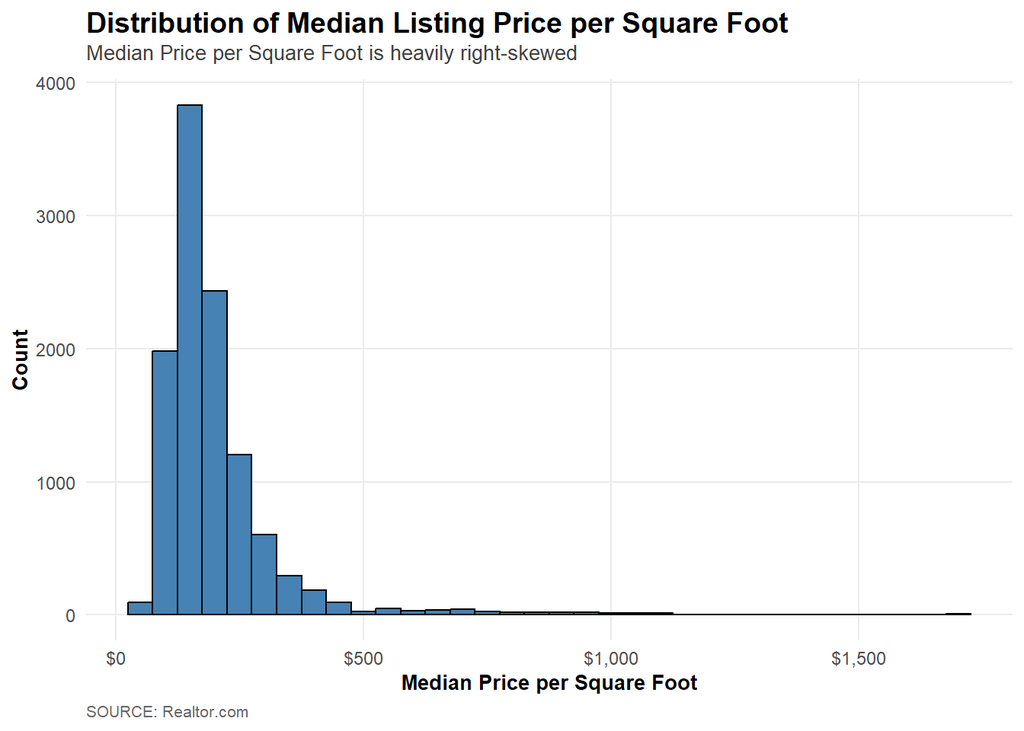

```r
price_dist_plt= ggplot(inventory_2024_filtered, aes(x = median_listing_price_per_square_foot)) +
  geom_histogram(binwidth = 50, fill = "steelblue", color = "black") +
  labs(
    title = "Distribution of Median Listing Price per Square Foot",
    subtitle = "Median Price per Square Foot is heavily right-skewed",
    x = "Median Price per Square Foot",
    y = "Count",
    caption = "SOURCE: Realtor.com") +
  scale_x_continuous(labels= dollar_format(accuracy=1))+
  theme_minimal(base_size = 11)+
  theme(plot.title=element_text(face="bold",size=14,margin=ggplot2::margin(b=3)),
  plot.subtitle = element_text(size=10,color="gray25",margin=ggplot2::margin(b=8)),
  plot.caption  = element_text(size=8,color="gray40",hjust=0),
  axis.title    = element_text(size=10,face="bold"),
  axis.text     = element_text(size=9),
  panel.grid.minor = element_blank(),
  panel.background  = element_blank(),
  plot.background   = element_blank())

ggsave(filename = "price_distribution.png",
  plot = price_dist_plt,
  width = 8,
  height = 5,
  dpi = 300)

price_dist_plt
```

The first distribution we plotted was median price per square foot- our main dependent variable. The graph shows that a majority of median listing prices per square foot fall below $500 with a handful of very high values pulling the mean of the graph higher than the median.

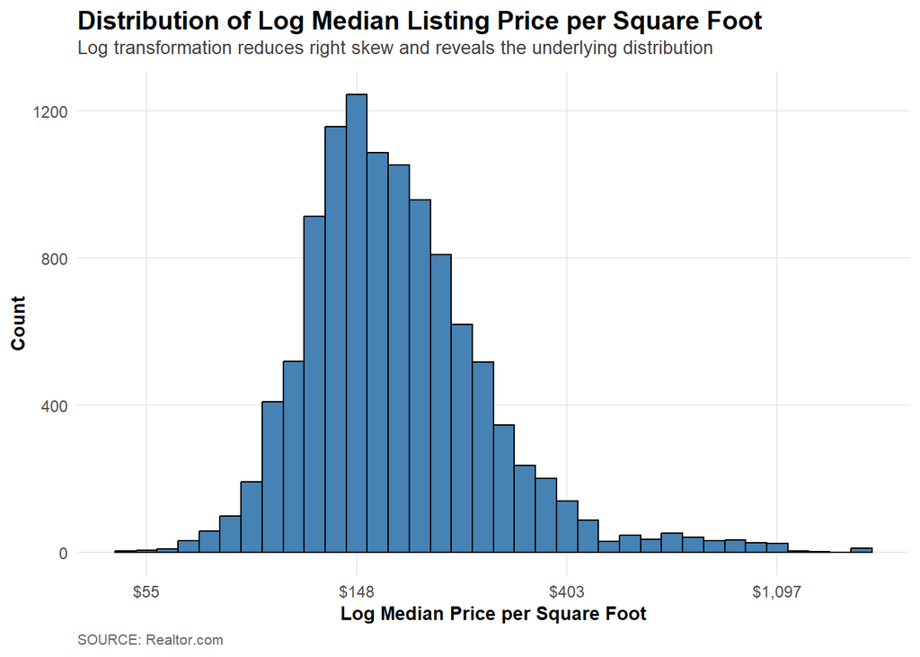

```r
logged_price_dist= ggplot(inventory_2024_filtered, aes(x = log_median_price_sqft)) +
  geom_histogram(binwidth = 0.1, fill = "steelblue", color = "black") +
  labs(title = "Distribution of Log Median Listing Price per Square Foot",
    subtitle = "Log transformation reduces right skew and reveals the underlying distribution",
    x = "Log Median Price per Square Foot",
    y = "Count",
    caption = "SOURCE: Realtor.com") +
  scale_x_continuous(
    labels = function(x) dollar(exp(x), accuracy = 1)) +
  theme_minimal(base_size = 11) +
  theme(plot.title    = element_text(face = "bold", size = 14, margin = ggplot2::margin(b = 3)),
    plot.subtitle = element_text(size = 10, color = "gray25", margin = ggplot2::margin(b = 8)),
    plot.caption  = element_text(size = 8, color = "gray40", hjust = 0),
    axis.title    = element_text(size = 10, face = "bold"),
    axis.text     = element_text(size = 9),
    panel.grid.minor = element_blank(),
    panel.background  = element_blank(),
    plot.background   = element_blank())

ggsave(filename = "logged_price_distribution.png",
  plot = logged_price_dist,
  width = 8,
  height = 5,
  dpi = 300)

logged_price_dist
```

Plotting the logged median price per square foot shows a distribution much closer to the normal curve. Logging the price mitigated the heavy influence of of outlier values and creates a more robust source from which to draw relationship insights between variables.

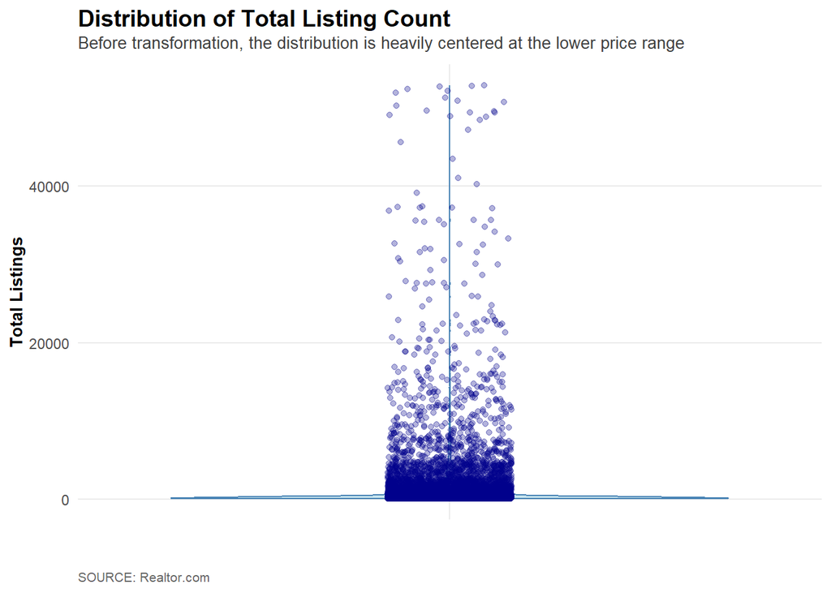

```r
housing_violion<- ggplot(inventory_2024_filtered, aes(x = "", y = total_listing_count)) +
  geom_violin(fill = "lightblue", color = "steelblue", alpha = 0.7) +
  geom_jitter(width = 0.1, alpha = 0.3, color = "darkblue") +
  labs(title = "Distribution of Total Listing Count",
    subtitle = "Before transformation, the distribution is heavily centered at the lower price range",
    x = "",
    y = "Total Listings",
    caption = "SOURCE: Realtor.com") +
  theme_minimal(base_size = 11) +
  theme(plot.title    = element_text(face="bold", size=14, margin=ggplot2::margin(b=3)),
    plot.subtitle = element_text(size=10, color="gray25", margin=ggplot2::margin(b=8)),
    plot.caption  = element_text(size=8, color="gray40", hjust=0),
    axis.title    = element_text(size=10, face="bold"),
    axis.text     = element_text(size=9),
    panel.grid.minor = element_blank(),
    panel.background  = element_blank(),
    plot.background   = element_blank())

housing_violion
```

This graph attempts to draw further insights into the distribution of listing counts among our cbsa units, but the concentration falling so heavily near the bottom of the y-axis makes it difficult to specifically interpret the supply distribution. To address this, we also plotted the log of supply below.

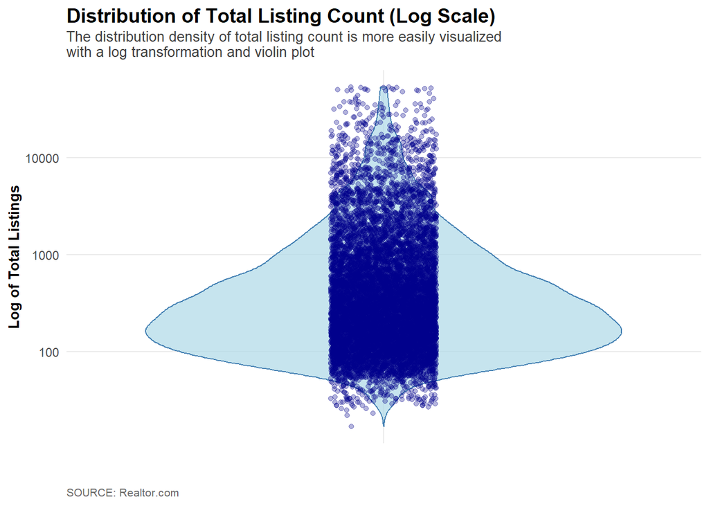

```r
log_housing_violin_plt= ggplot(inventory_2024_filtered, aes(x = "", y = total_listing_count)) +
  geom_violin(fill = "lightblue", color = "steelblue", alpha = 0.7) +
  geom_jitter(width = 0.1, alpha = 0.3, color = "darkblue") +
  scale_y_log10() +
  labs(title = "Distribution of Total Listing Count (Log Scale)",
    subtitle = "The distribution density of total listing count is more easily visualized\nwith a log transformation and violin plot",
    x = "",
    y = "Log of Total Listings",
    caption = "SOURCE: Realtor.com") +
  theme_minimal(base_size = 11) +
  theme(
    plot.title    = element_text(face="bold", size=14, margin=ggplot2::margin(b=3)),
    plot.subtitle = element_text(size=10, color="gray25", margin=ggplot2::margin(b=8)),
    plot.caption  = element_text(size=8, color="gray40", hjust=0),
    axis.title    = element_text(size=10, face="bold"),
    axis.text     = element_text(size=9),
    panel.grid.minor = element_blank(),
    panel.background  = element_blank(),
    plot.background   = element_blank())

ggsave(filename = "logged_supply_violin.png",
  plot = log_housing_violin_plt,
  width = 8,
  height = 5,
  dpi = 300)
log_housing_violin_plt
```

This graph shows the log distribution of listing supply overlayed on top of a violin plot of the same data. This added dimension and logged variable adds much more insight into the distribution of the supply variable. As the graph demonstrates, a majority of the supply variables land near the bottom of the y-axis, indicating that there are vastly more cbsa with low listing counts than high listing counts. This is likely due to the structure of our cbsa data. Micro areas can be cbsa regions with 10,000-50,000 residents, and macro areas are any over 50,000 residents. Most small towns fall in the micro level, whereas some massive metropolitan areas (like New York, Chicago, Los Angeles) have millions of residents. This leads to a vast majority of the units falling on the lower end of the spectrum with large, meaningful outliers near the top. For further graphs, we also plotted the log of supply to help normalize this distribution and draw out the true nature of the relationships between variables.

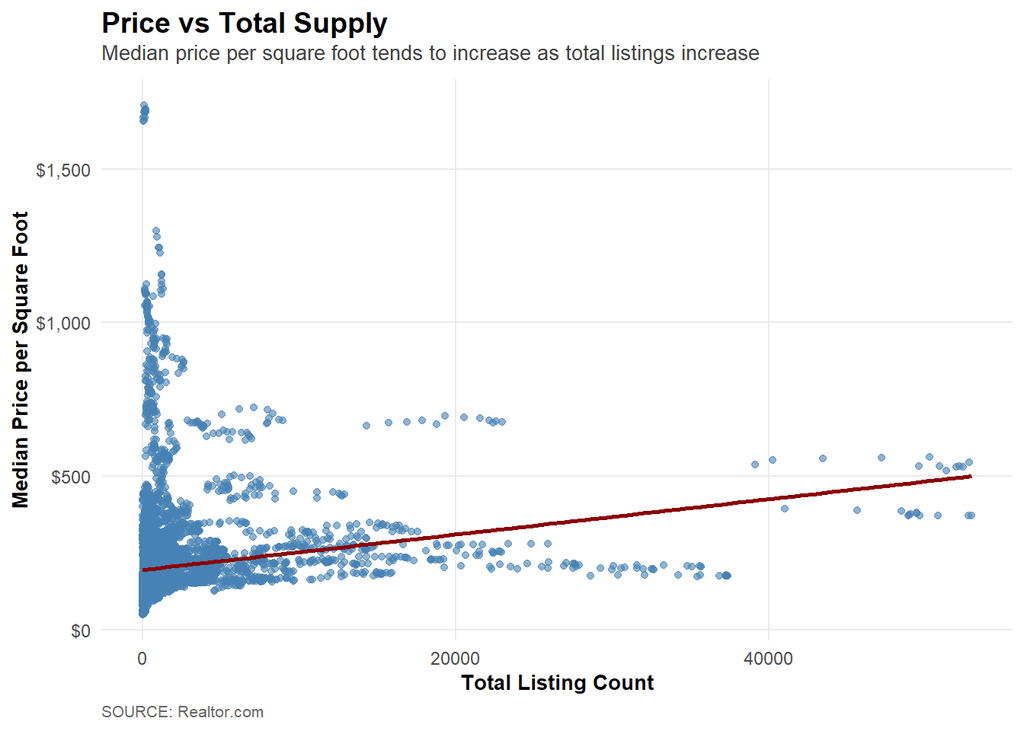

```r
price_supply_scatter= ggplot(inventory_2024_filtered, aes(x = total_listing_count, y = median_listing_price_per_square_foot)) +
  geom_point(alpha = 0.6, color = "steelblue") +
  geom_smooth(method = "lm", se = FALSE, color = "darkred", linewidth = 1) +
  labs(title = "Price vs Total Supply",
       subtitle = "Median price per square foot tends to increase as total listings increase",
       x = "Total Listing Count",
       y = "Median Price per Square Foot",
       caption = "SOURCE: Realtor.com") +
  scale_y_continuous(labels = dollar_format(accuracy = 1)) +
  theme_minimal(base_size = 11) +
  theme(plot.title    = element_text(face="bold", size=14, margin=ggplot2::margin(b=3)),
        plot.subtitle = element_text(size=10, color="gray25", margin=ggplot2::margin(b=8)),
        plot.caption  = element_text(size=8, color="gray40", hjust=0),
        axis.title    = element_text(size=10, face="bold"),
        axis.text     = element_text(size=9),
        panel.grid.minor = element_blank(),
        panel.background  = element_blank(),
        plot.background   = element_blank())

ggsave(filename = "pricesupply_scatter.png",
  plot = price_supply_scatter,
  width = 8,
  height = 5,
  dpi = 300)

price_supply_scatter
```

This graph plots the relationship between the un-transformed price and supply variables as this is the key relationship driving our SMART question. This plot shows how price appears to be positively correlated with total listing count, but we procedded with log transformations of the variables to be sure.

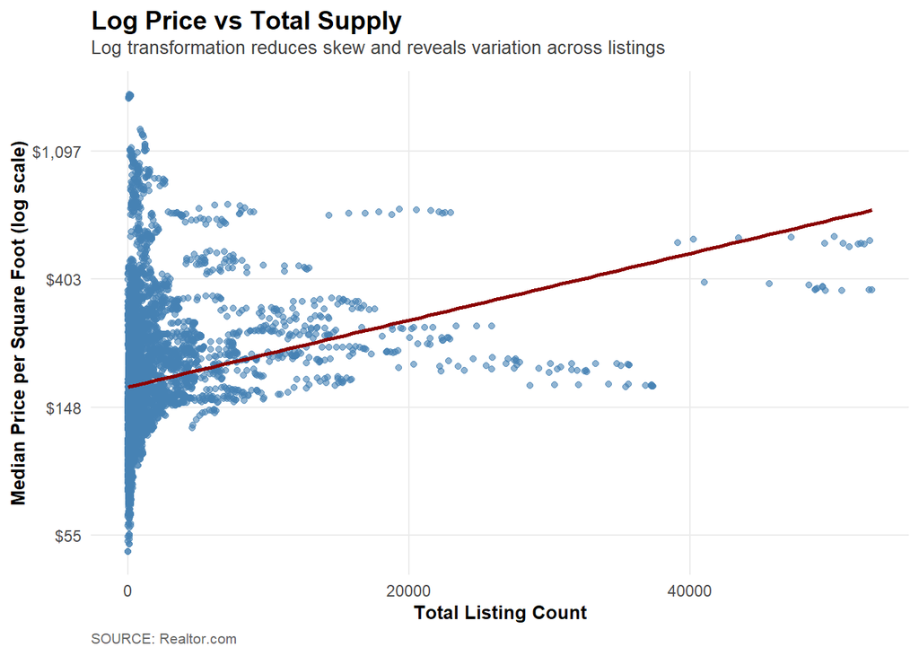

```r
log_price_supply_scatter <- ggplot(inventory_2024_filtered, aes(x = total_listing_count, y = log_median_price_sqft)) +
  geom_point(alpha = 0.6, color = "steelblue") +
  geom_smooth(method = "lm", se = FALSE, color = "darkred", linewidth = 1) +
  labs(title = "Log Price vs Total Supply",
       subtitle = "Log transformation reduces skew and reveals variation across listings",
       x = "Total Listing Count",
       y = "Median Price per Square Foot (log scale)",
       caption = "SOURCE: Realtor.com") +
  scale_y_continuous(labels = function(x) dollar(exp(x), accuracy = 1)) +
  theme_minimal(base_size = 11) +
  theme(plot.title    = element_text(face="bold", size=14, margin=ggplot2::margin(b=3)),
        plot.subtitle = element_text(size=10, color="gray25", margin=ggplot2::margin(b=8)),
        plot.caption  = element_text(size=8, color="gray40", hjust=0),
        axis.title    = element_text(size=10, face="bold"),
        axis.text     = element_text(size=9),
        panel.grid.minor = element_blank(),
        panel.background  = element_blank(),
        plot.background   = element_blank())

log_price_supply_scatter
```

After plotting the lof of our price variable against our supply variable, the positive relationship between price and supply appears even stronger than in our previous graph. However, the distribution of supply is still heavily skewed, so we also logged that variable for the next graph.

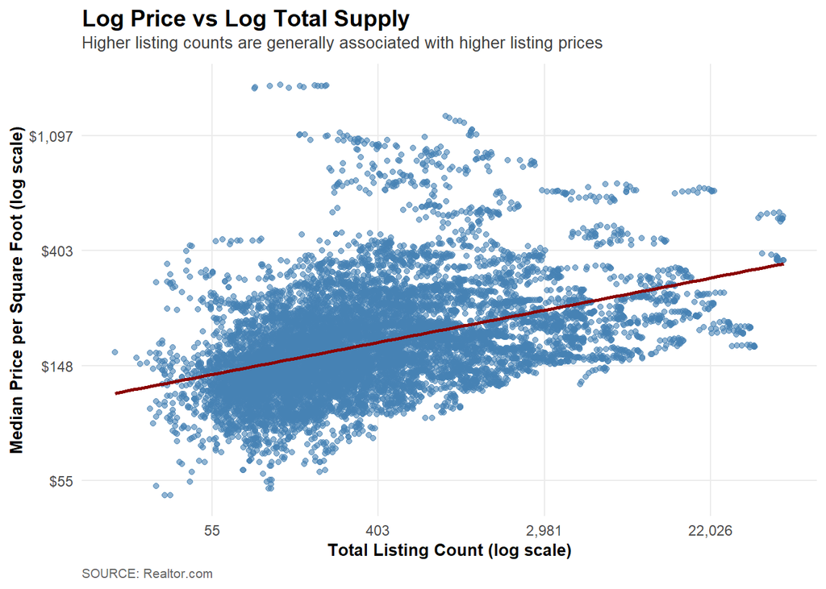

```r
#log by log scatter with a regression line on top and the actual values associated with the log transformation
log_price_log_supply_scatter<- ggplot(inventory_2024_filtered,
       aes(x = log(total_listing_count),
           y = log(median_listing_price_per_square_foot))) +
  geom_point(alpha = 0.6, color = "steelblue") +
  geom_smooth(method = "lm", se = FALSE, color = "darkred", linewidth = 1) +
  scale_x_continuous(name = "Total Listing Count (log scale)",
    labels = function(x) scales::comma(round(exp(x)))) +
  scale_y_continuous(
    name = "Median Price per Square Foot (log scale)",
    labels = function(y) scales::dollar(round(exp(y), 0))) +
  labs(title = "Log Price vs Log Total Supply",
    subtitle = "Higher listing counts are generally associated with higher listing prices",
    caption = "SOURCE: Realtor.com") +
  theme_minimal(base_size = 11) +
  theme(plot.title    = element_text(face="bold", size=14, margin = ggplot2::margin(b=3)),
    plot.subtitle = element_text(size=10, color="gray25", margin = ggplot2::margin(b=8)),
    plot.caption  = element_text(size=8, color="gray40", hjust=0),
    axis.title    = element_text(size=10, face="bold"),
    axis.text     = element_text(size=9),
    panel.grid.minor = element_blank(),
    panel.background  = element_blank(),
    plot.background   = element_blank())

log_price_log_supply_scatter
```

In this final version of our price/ supply scatterplot, we compare the log of price with the log of supply, and we see a clear positive trend between price and supply. Log of median price per square foot steadily increases as log of total listing count increases, supporting the idea that changes in housing supply- at least partially- influence changes in housing price.

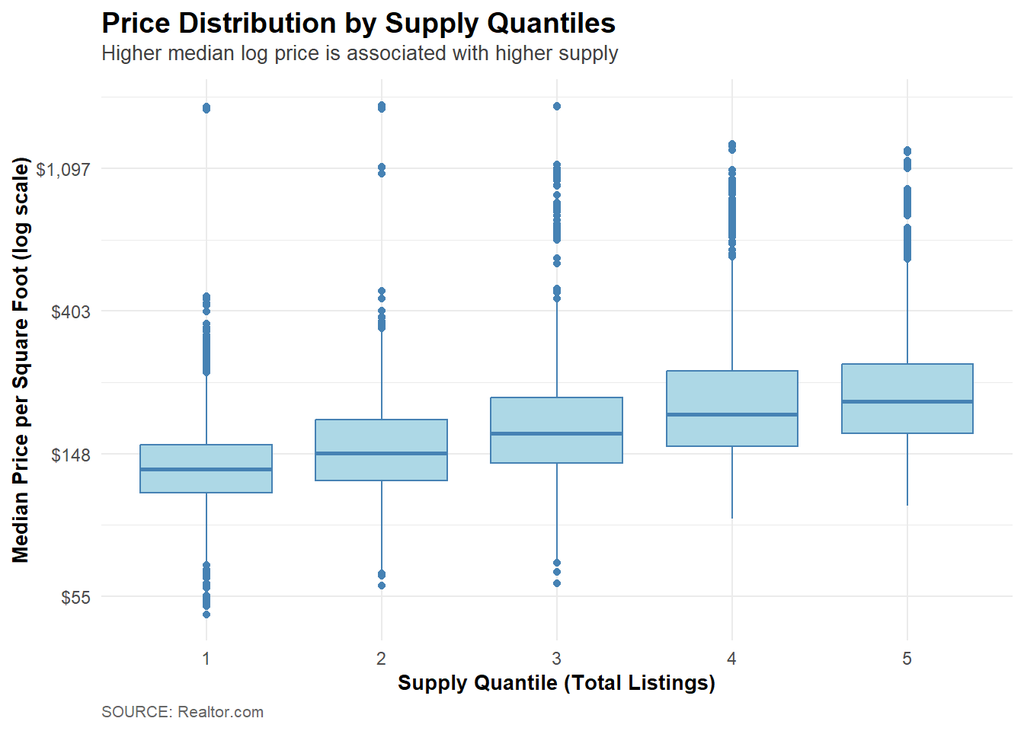

```r
logprice_logsupply_scatter= inventory_2024_filtered %>%
  mutate(listing_bin = ntile(total_listing_count, 5)) %>%
  ggplot(aes(x = factor(listing_bin), y = log_median_price_sqft)) +
  geom_boxplot(fill = "lightblue", color = "steelblue") +
  scale_y_continuous(
    name = "Median Price per Square Foot (log scale)",
    labels = function(y) scales::dollar(round(exp(y), 0))) +
  labs(
    title = "Price Distribution by Supply Quantiles",
    subtitle= "Higher median log price is associated with higher supply",
    x = "Supply Quantile (Total Listings)",
    y = "Median Price per Sq Ft (log)",
    caption = "SOURCE: Realtor.com") +
  theme_minimal(base_size = 11) +
  theme(
    plot.title    = element_text(face="bold", size=14, margin = ggplot2::margin(b=3)),
    plot.subtitle = element_text(size=10, color="gray25", margin = ggplot2::margin(b=8)),
    plot.caption  = element_text(size=8, color="gray40", hjust=0),
    axis.title    = element_text(size=10, face="bold"),
    axis.text     = element_text(size=9))

ggsave(filename = "logpricelogsupply_scatter.png",
  plot = logprice_logsupply_scatter,
  width = 8,
  height = 5,
  dpi = 300)

logprice_logsupply_scatter
```

When separating unlogged supply into quantiles for a boxplot, the positive correlation between these two variables remains plainly visible.

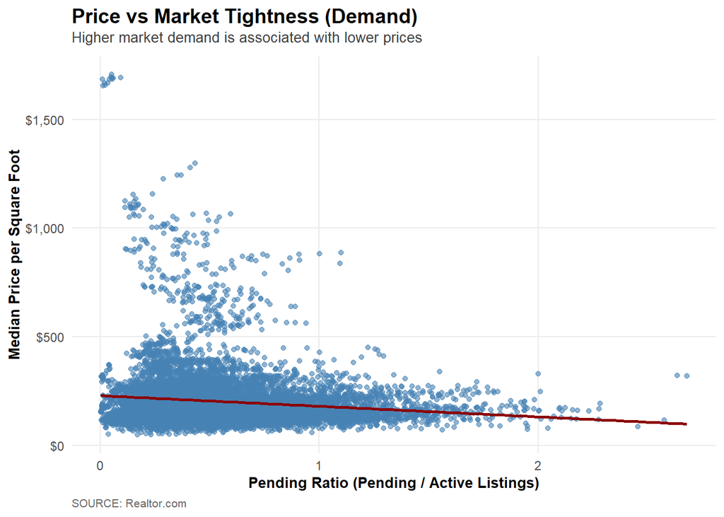

```r
Price_demand_scatter= ggplot(inventory_2024_filtered, aes(x = pending_ratio, y = median_listing_price_per_square_foot)) +
  geom_point(alpha = 0.6, color = "steelblue") +
  geom_smooth(method = "lm", se = FALSE, color = "darkred", linewidth = 1) +
  scale_y_continuous(labels = dollar_format(accuracy = 1)) +
  labs(title = "Price vs Market Tightness (Demand)",
    subtitle = "Higher market demand is associated with lower prices",
    x = "Pending Ratio (Pending / Active Listings)",
    y = "Median Price per Square Foot",
    caption = "SOURCE: Realtor.com") +
  theme_minimal(base_size = 11) +
  theme(plot.title    = element_text(face="bold", size=14, margin = ggplot2::margin(b=3)),
    plot.subtitle = element_text(size=10, color="gray25", margin = ggplot2::margin(b=8)),
    plot.caption  = element_text(size=8, color="gray40", hjust=0),
    axis.title    = element_text(size=10, face="bold"),
    axis.text     = element_text(size=9),
    panel.grid.minor = element_blank(),
    panel.background  = element_blank(),
    plot.background   = element_blank())

ggsave(filename = "pricedemand_scatter.png",
  plot = Price_demand_scatter,
  width = 8,
  height = 5,
  dpi = 300)

Price_demand_scatter
```

The next relationship we investigated was the relationship between housing price and market demand. As is clean in the graph above, plotting median listing price per square foot against pending ratio (our proxy for market demand), reveals a slight negative relationship between price and demand. This is in line with traditional models of supply and demand where where supply is held constant, and higher demand is associated with lower market prices.

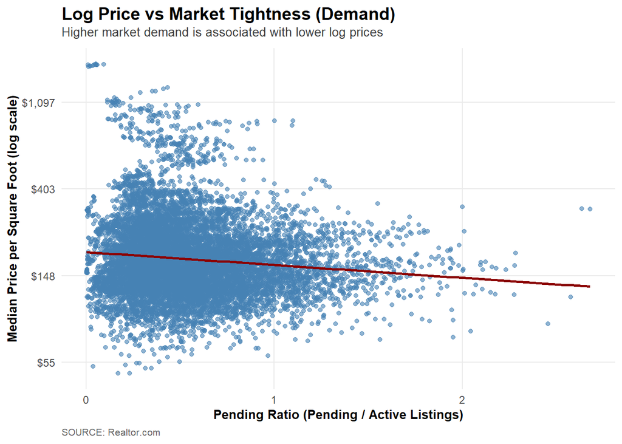

```r
logprice_demand_scatter= ggplot(inventory_2024_filtered, aes(x = pending_ratio, y = log_median_price_sqft)) +
  geom_point(alpha = 0.6, color = "steelblue") +
  geom_smooth(method = "lm", se = FALSE, color = "darkred", linewidth = 1) +
  scale_y_continuous(
    labels = function(x) dollar(exp(x), accuracy = 1)) +
  labs(title = "Log Price vs Market Tightness (Demand)",
    subtitle = "Higher market demand is associated with lower log prices",
    x = "Pending Ratio (Pending / Active Listings)",
    y = "Median Price per Square Foot (log scale)",
    caption = "SOURCE: Realtor.com") +
  theme_minimal(base_size = 11) +
  theme(plot.title    = element_text(face="bold", size=14, margin = ggplot2::margin(b=3)),
    plot.subtitle = element_text(size=10, color="gray25", margin = ggplot2::margin(b=8)),
    plot.caption  = element_text(size=8, color="gray40", hjust=0),
    axis.title    = element_text(size=10, face="bold"),
    axis.text     = element_text(size=9),
    panel.grid.minor = element_blank(),
    panel.background  = element_blank(),
    plot.background   = element_blank())

ggsave(filename = "logpricedemand_scatter.png",
  plot = logprice_demand_scatter,
  width = 8,
  height = 5,
  dpi = 300)

logprice_demand_scatter
```

We also graphed the relationship between log price and market demand, and the negative correlation between these relationships persists.

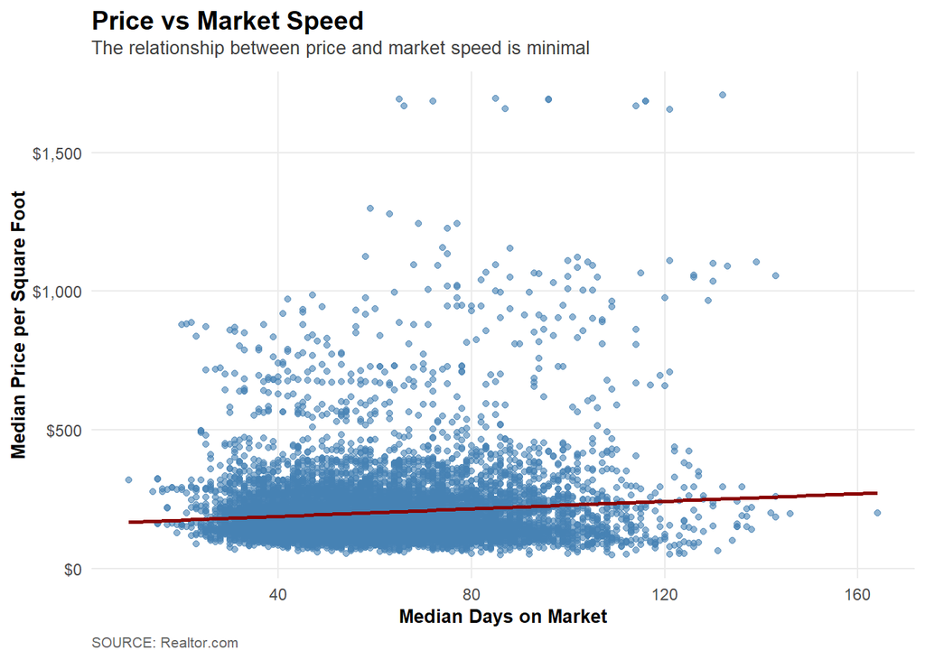

```r
price_market_hotness_plot <-ggplot(inventory_2024_filtered, aes(x = median_days_on_market, y = median_listing_price_per_square_foot)) +
  geom_point(alpha = 0.6, color = "steelblue") +
  geom_smooth(method = "lm", se = FALSE, color = "darkred", linewidth = 1) +
  scale_y_continuous(labels = dollar_format(accuracy = 1)) +
  labs(title = "Price vs Market Speed",
    subtitle = "The relationship between price and market speed is minimal",
    x = "Median Days on Market",
    y = "Median Price per Square Foot",
    caption = "SOURCE: Realtor.com") +
  theme_minimal(base_size = 11) +
  theme(plot.title    = element_text(face="bold", size=14, margin = ggplot2::margin(b=3)),
    plot.subtitle = element_text(size=10, color="gray25", margin = ggplot2::margin(b=8)),
    plot.caption  = element_text(size=8, color="gray40", hjust=0),
    axis.title    = element_text(size=10, face="bold"),
    axis.text     = element_text(size=9),
    panel.grid.minor = element_blank(),
    panel.background  = element_blank(),
    plot.background   = element_blank())

price_market_hotness_plot
```

The next set of variables that we investigated in our exploratory data analysis was price and market speed. The graph above shows a slight positive relationship between price and market speed (represented with the median days on market variable), although the magnitude of the relationship appears small. Additionally, we cannot claim causality in this relationship as the risk of reverse causality is very high between these variables. We would require a much more thorough study to investigate any causal relationship between these variables.

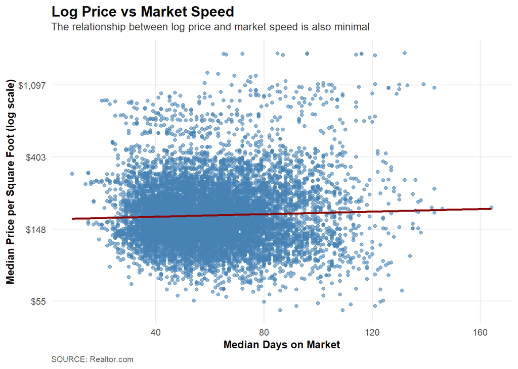

```r
log_price_market_hotness_plot<- ggplot(inventory_2024_filtered, aes(x = median_days_on_market, y = log_median_price_sqft)) +
  geom_point(alpha = 0.6, color = "steelblue") +
  geom_smooth(method = "lm", se = FALSE, color = "darkred", linewidth = 1) +
  scale_y_continuous(labels = function(x) dollar(exp(x), accuracy = 1)) +
  labs(title = "Log Price vs Market Speed",
    subtitle = "The relationship between log price and market speed is also minimal",
    x = "Median Days on Market",
    y = "Median Price per Square Foot (log scale)",
    caption = "SOURCE: Realtor.com") +
  theme_minimal(base_size = 11) +
  theme(plot.title    = element_text(face="bold", size=14, margin = ggplot2::margin(b=3)),
    plot.subtitle = element_text(size=10, color="gray25", margin = ggplot2::margin(b=8)),
    plot.caption  = element_text(size=8, color="gray40", hjust=0),
    axis.title    = element_text(size=10, face="bold"),
    axis.text     = element_text(size=9),
    panel.grid.minor = element_blank(),
    panel.background  = element_blank(),
    plot.background   = element_blank())

log_price_market_hotness_plot
```

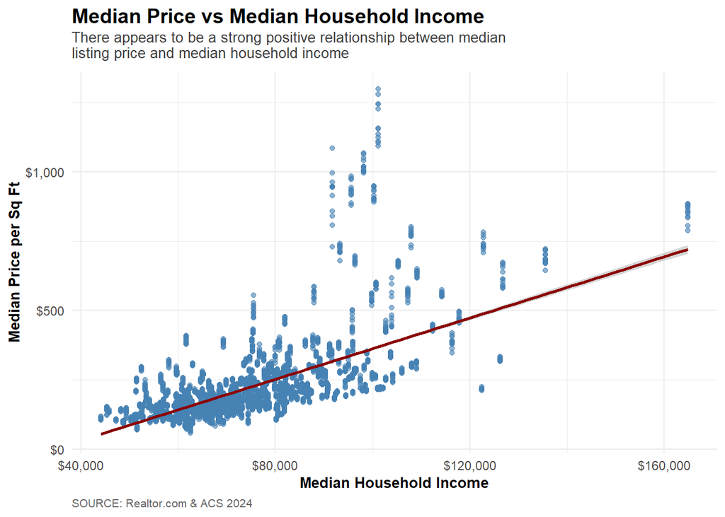

```r
price_income_scatter= ggplot(full_dataset_clean, aes(x = median_household_income,
                               y = median_listing_price_per_square_foot)) +
  geom_point(alpha = 0.6, color = "steelblue") +
  geom_smooth(method = "lm", se = TRUE, color = "darkred", linewidth = 1) +
  scale_x_continuous(labels = scales::dollar) +
  scale_y_continuous(labels = scales::dollar) +
  labs(title = "Median Price vs Median Household Income",
    subtitle = "There appears to be a strong positive relationship between median\nlisting price and median household income",
    x = "Median Household Income",
    y = "Median Price per Sq Ft",
    caption = "SOURCE: Realtor.com & ACS 2024") +
  theme_minimal(base_size = 11) +
  theme(plot.title    = element_text(face="bold", size=14, margin=ggplot2::margin(b=3)),
    plot.subtitle = element_text(size=10, color="gray25", margin=ggplot2::margin(b=8)),
    plot.caption  = element_text(size=8, color="gray40", hjust=0),
    axis.title    = element_text(size=10, face="bold"),
    axis.text     = element_text(size=9))

ggsave(filename = "priceincome_scatter.png",
  plot = price_income_scatter,
  width = 8,
  height = 5,
  dpi = 300)

price_income_scatter
```

The final set of variables we analyzed was median price per square foot and median household income. We expected a strong, positive relationship between these variables, and as is plainly visible in the graph above, that is exactly what we found. Again, this is in line with classic models of supply and demand. However, neither of these variables have normal distributions, so we also compared their log transformations.

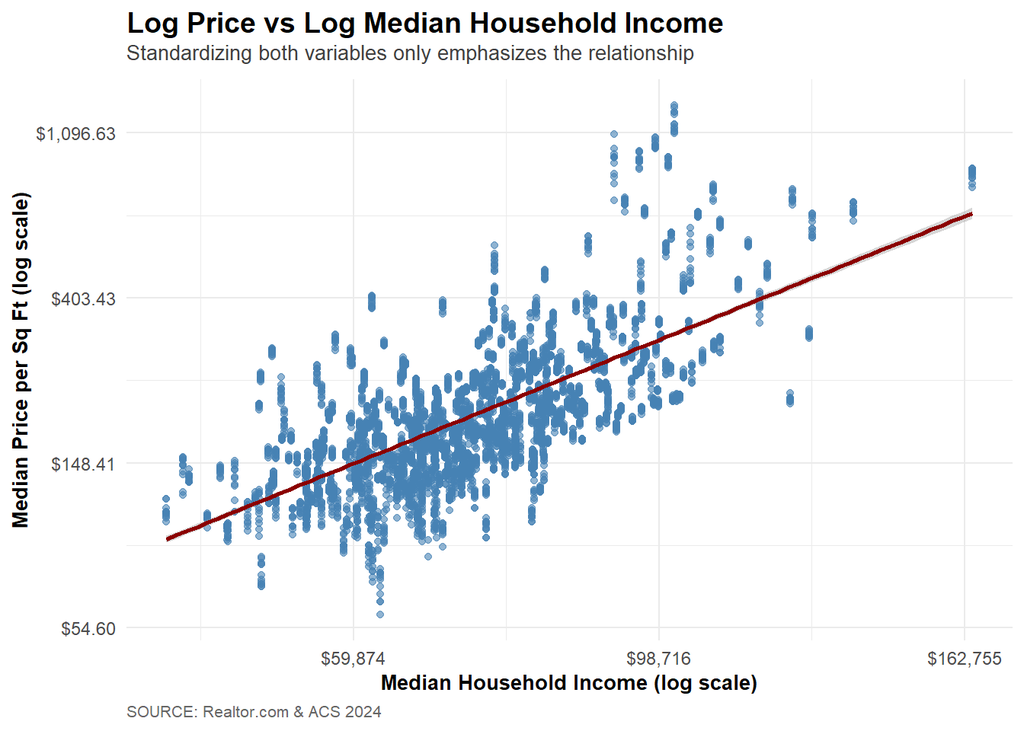

```r
logprice_logincome_scatter= ggplot(full_dataset_clean) +
  geom_point(aes(x = log(median_household_income),
                 y = log(median_listing_price_per_square_foot)),
             alpha = 0.6, color = "steelblue") +
  geom_smooth(aes(x = log(median_household_income),
                  y = log(median_listing_price_per_square_foot)),
              method = "lm", se = TRUE, color = "darkred", linewidth = 1) +
  scale_x_continuous(name = "Median Household Income (log scale)",
    labels = function(x) scales::dollar(exp(x))) +
  scale_y_continuous(name = "Median Price per Sq Ft (log scale)",
    labels = function(y) scales::dollar(exp(y))) +
  labs(title = "Log Price vs Log Median Household Income",
    subtitle = "Standardizing both variables only emphasizes the relationship",
    caption = "SOURCE: Realtor.com & ACS 2024") +
  theme_minimal(base_size = 11) +
  theme(plot.title    = element_text(face="bold", size=14, margin=ggplot2::margin(b=3)),
    plot.subtitle = element_text(size=10, color="gray25", margin=ggplot2::margin(b=8)),
    plot.caption  = element_text(size=8, color="gray40", hjust=0),
    axis.title    = element_text(size=10, face="bold"),
    axis.text     = element_text(size=9))

ggsave(filename = "logpricelogincome_scatter.png",
  plot = logprice_logincome_scatter,
  width = 8,
  height = 5,
  dpi = 300)

logprice_logincome_scatter
```

When plotting log price and log income, the positive relationship between the variables is of an even larger magnitude than the un-transformed versions of the variables. This demonstrates a clear and strong relationship and the potential significance of income as a predictor in our models.

## Modeling

EDA cannot establish causality by itself, but it does provide a strong starting point for more complex statistical testing of the data.

### Split the Data into train and test

```r
set.seed(4)

targets = c("median_listing_price_per_square_foot", "log_median_price_sqft")

split = sample.split(full_dataset_clean$GEOID, SplitRatio = 0.8)
train = subset(full_dataset_clean %>% select(-"GEOID"), split == TRUE)
test = subset(full_dataset_clean %>% select(-"GEOID"), split == FALSE)

# train
price_train = train$median_listing_price_per_square_foot
log_price_train = train$log_median_price_sqft

X_train = train %>% select(-all_of(targets))
X_train_matrix = model.matrix(~.-1,X_train)

X_train_no_cbsa = X_train %>% select(-cbsa_title)
X_train_no_cbsa_matrix = model.matrix(~.-1,X_train_no_cbsa)

# test
price_test = test$median_listing_price_per_square_foot
log_price_test = test$log_median_price_sqft

X_test = test %>% select(-all_of(targets))
X_test_matrix = model.matrix(~.-1,X_test)

X_test_no_cbsa = X_test %>% select(-cbsa_title)
X_test_no_cbsa_matrix = model.matrix(~.-1,X_test_no_cbsa)
```

The data is split, with 80% for training and 20% for testing. For the purposes of this study, both the median listing price per square foot and its log were used as target variables, so that they may be compared.

Matrices are also prepared for use by LASSO.

### Linear Regression

#### Median Listing Price per Square Foot

```r
reg_model_by_1 <- lm(median_listing_price_per_square_foot ~ total_listing_count,
            data = train)

summary(reg_model_by_1)
```

```
##
## Call:
## lm(formula = median_listing_price_per_square_foot ~ total_listing_count,
##     data = train)
##
## Residuals:
##    Min     1Q Median     3Q    Max
## -204.8  -68.2  -30.2   23.0 1065.0
##
## Coefficients:
##                       Estimate Std. Error t value Pr(>|t|)
## (Intercept)         209.640034   1.921284   109.1   <2e-16 ***
## total_listing_count   0.004556   0.000366    12.4   <2e-16 ***
## ---
## Signif. codes:  0 '***' 0.001 '**' 0.01 '*' 0.05 '.' 0.1 ' ' 1
##
## Residual standard error: 128 on 5231 degrees of freedom
## Multiple R-squared:  0.0288, Adjusted R-squared:  0.0286
## F-statistic:  155 on 1 and 5231 DF,  p-value: <2e-16
```

First, a linear model is fit with `total_listing_count` as the only predictor. With such a simple model, it is perhaps not surprising that the Multiple R-squared is so low—0.0288—though this is still highly significant. However, as the estimate of this coefficient is positive, this model would seem to imply that increased supply is correlated with increased price per square foot. Perhaps more information will be more instructive.

```r
reg_model_by_all <- lm(median_listing_price_per_square_foot ~ .-cbsa_title-log_median_price_sqft,
            data = train)

summary(reg_model_by_all)
```

```
##
## Call:
## lm(formula = median_listing_price_per_square_foot ~ . - cbsa_title -
##     log_median_price_sqft, data = train)
##
## Residuals:
##    Min     1Q Median     3Q    Max
## -219.7  -32.1   -2.1   26.2  556.6
##
## Coefficients:
##                              Estimate    Std. Error t value Pr(>|t|)
## (Intercept)             -8845.9248917 50189.5044941   -0.18  0.86010
## total_population            0.0000709     0.0000119    5.98  2.4e-09 ***
## pct_female                  2.4375101     0.9224434    2.64  0.00826 **
## pct_white                  -3.3909536     0.4911432   -6.90  5.7e-12 ***
## pct_black                  -3.8852373     0.5029785   -7.72  1.3e-14 ***
## pct_aian                   -3.5247886     0.5352760   -6.58  5.0e-11 ***
## pct_asian                  -2.8157779     0.6672297   -4.22  2.5e-05 ***
## pct_nhpi                   22.4770681     1.6719943   13.44  < 2e-16 ***
## pct_two_or_more            -4.0802497     0.3878300  -10.52  < 2e-16 ***
## pct_hispanic                0.4671647     0.2961200    1.58  0.11471
## median_age                  2.4508771     0.4051798    6.05  1.6e-09 ***
## pct_under_18               -4.1705049     0.6532789   -6.38  1.9e-10 ***
## total_households           -0.0009366     0.0001044   -8.97  < 2e-16 ***
## pct_married_couple         -4.4202959     0.6194868   -7.14  1.1e-12 ***
## pct_male_householder       -8.5572505     0.7520751  -11.38  < 2e-16 ***
## pct_female_householder     -3.7096113     0.7323602   -5.07  4.2e-07 ***
## pct_unemployed             -7.5248864     1.2340013   -6.10  1.2e-09 ***
## pct_below_poverty          -0.8776696     0.5437292   -1.61  0.10655
## pct_income_10_14999         1.2672191     1.1189377    1.13  0.25747
## pct_income_15_24999         6.6273718     1.0104158    6.56  5.9e-11 ***
## pct_income_25_34999         3.5914555     1.0064759    3.57  0.00036 ***
## pct_income_35_49999         4.5561182     0.8579653    5.31  1.1e-07 ***
## pct_income_50_74999         3.6882698     0.8404993    4.39  1.2e-05 ***
## pct_income_75_99999         0.0894807     1.0469556    0.09  0.93189
## pct_income_100_149k         4.7500064     1.0177460    4.67  3.1e-06 ***
## pct_income_150_199k         1.9035372     1.1177579    1.70  0.08863 .
## pct_income_200k_plus        8.3107327     1.2237206    6.79  1.2e-11 ***
## median_household_income     0.0042429     0.0003796   11.18  < 2e-16 ***
## pct_high_school_plus       -0.0673494     0.4530865   -0.15  0.88184
```

[output cut: 14 more lines]

```
## pct_2_bed                  -6.0047784     0.7778107   -7.72  1.4e-14 ***
## pct_3_bed                  -5.7643616     0.7913148   -7.28  3.7e-13 ***
## pct_4_bed                 -10.1503354     0.8250897  -12.30  < 2e-16 ***
## pct_5plus_bed              -4.8878482     0.8743573   -5.59  2.4e-08 ***
## area_typeMicro             20.8463748     2.4677002    8.45  < 2e-16 ***
## month_date_yyyymm           0.0479433     0.2479423    0.19  0.84668
## total_listing_count        -0.0058566     0.0005451  -10.74  < 2e-16 ***
## pending_ratio             -12.2510452     3.1841257   -3.85  0.00012 ***
## median_days_on_market       0.3178351     0.0642984    4.94  7.9e-07 ***
## ---
## Signif. codes:  0 '***' 0.001 '**' 0.01 '*' 0.05 '.' 0.1 ' ' 1
##
## Residual standard error: 59.7 on 5181 degrees of freedom
## Multiple R-squared:  0.789,  Adjusted R-squared:  0.787
## F-statistic:  380 on 51 and 5181 DF,  p-value: <2e-16
```

#### Log Median Listing Price per Square Foot

```r
# names(full_dataset_clean)
#reg d- "avg_log_median_listing_price" i- "total_active_listing_count"
reg_model_log_by_1 <- lm(log_median_price_sqft ~ total_listing_count,
            data = train)

summary(reg_model_log_by_1)
```

```
##
## Call:
## lm(formula = log_median_price_sqft ~ total_listing_count, data = train)
##
## Residuals:
##    Min     1Q Median     3Q    Max
## -1.169 -0.274 -0.046  0.202  1.893
##
## Coefficients:
##                       Estimate Std. Error t value Pr(>|t|)
## (Intercept)         5.24253933 0.00624529   839.4   <2e-16 ***
## total_listing_count 0.00001945 0.00000119    16.4   <2e-16 ***
## ---
## Signif. codes:  0 '***' 0.001 '**' 0.01 '*' 0.05 '.' 0.1 ' ' 1
##
## Residual standard error: 0.414 on 5231 degrees of freedom
## Multiple R-squared:  0.0486, Adjusted R-squared:  0.0485
## F-statistic:  267 on 1 and 5231 DF,  p-value: <2e-16
```

Logging the dependent variable nearly doubles the Multiple R-squared relative to the unlogged specification, indicating a modest improvement in fit. This suggests the log transformation reduces skew and the influence of extreme values. Even then, the model still explains only a limited share of the variation in price per square foot.

```r
#reg d- "avg_log_median_listing_price" i- "total_active_listing_count" "area_type" "avg_pct_income_75k_plus" "avg_pct_units_built_2000_plus" "avg_pct_bachelors_or_higher"
reg_model_log_by_all <- lm(log_median_price_sqft ~ . -cbsa_title -median_listing_price_per_square_foot,
            data = train)

summary(reg_model_log_by_all)
```

```
##
## Call:
## lm(formula = log_median_price_sqft ~ . - cbsa_title - median_listing_price_per_square_foot,
##     data = train)
##
## Residuals:
##     Min      1Q  Median      3Q     Max
## -0.6310 -0.1124 -0.0033  0.1109  0.8750
##
## Coefficients:
##                                Estimate      Std. Error t value Pr(>|t|)
## (Intercept)             -263.9506517811  147.1815778591   -1.79  0.07297 .
## total_population           0.0000000435    0.0000000348    1.25  0.21117
## pct_female                 0.0216150690    0.0027050809    7.99  1.6e-15 ***
## pct_white                 -0.0183854352    0.0014402858  -12.77  < 2e-16 ***
## pct_black                 -0.0220597433    0.0014749931  -14.96  < 2e-16 ***
## pct_aian                  -0.0154160110    0.0015697061   -9.82  < 2e-16 ***
## pct_asian                 -0.0197734811    0.0019566624  -10.11  < 2e-16 ***
## pct_nhpi                   0.0209086486    0.0049031519    4.26  2.0e-05 ***
## pct_two_or_more           -0.0152579070    0.0011373182  -13.42  < 2e-16 ***
## pct_hispanic              -0.0017765348    0.0008683769   -2.05  0.04083 *
## median_age                 0.0083844151    0.0011881966    7.06  1.9e-12 ***
## pct_under_18              -0.0222256671    0.0019157515  -11.60  < 2e-16 ***
## total_households          -0.0000026152    0.0000003060   -8.55  < 2e-16 ***
## pct_married_couple        -0.0138774853    0.0018166557   -7.64  2.6e-14 ***
## pct_male_householder      -0.0281977982    0.0022054730  -12.79  < 2e-16 ***
## pct_female_householder    -0.0152457556    0.0021476587   -7.10  1.4e-12 ***
## pct_unemployed            -0.0044214173    0.0036187298   -1.22  0.22183
## pct_below_poverty         -0.0064797076    0.0015944951   -4.06  4.9e-05 ***
## pct_income_10_14999        0.0156180661    0.0032813040    4.76  2.0e-06 ***
## pct_income_15_24999        0.0178654188    0.0029630616    6.03  1.8e-09 ***
## pct_income_25_34999        0.0169949240    0.0029515076    5.76  9.0e-09 ***
## pct_income_35_49999        0.0202519328    0.0025159978    8.05  1.0e-15 ***
## pct_income_50_74999        0.0187283084    0.0024647786    7.60  3.5e-14 ***
## pct_income_75_99999        0.0203351809    0.0030702150    6.62  3.9e-11 ***
## pct_income_100_149k        0.0353523476    0.0029845575   11.85  < 2e-16 ***
## pct_income_150_199k        0.0409031617    0.0032778441   12.48  < 2e-16 ***
## pct_income_200k_plus       0.0521975589    0.0035885816   14.55  < 2e-16 ***
## median_household_income    0.0000004796    0.0000011133    0.43  0.66666
## pct_high_school_plus       0.0002452845    0.0013286839    0.18  0.85354
```

[output cut: 14 more lines]

```
## pct_2_bed                 -0.0158731141    0.0022809431   -6.96  3.9e-12 ***
## pct_3_bed                 -0.0182188726    0.0023205442   -7.85  5.0e-15 ***
## pct_4_bed                 -0.0278601810    0.0024195897  -11.51  < 2e-16 ***
## pct_5plus_bed             -0.0139748305    0.0025640677   -5.45  5.3e-08 ***
## area_typeMicro             0.0745508272    0.0072365730   10.30  < 2e-16 ***
## month_date_yyyymm          0.0013381116    0.0007270949    1.84  0.06577 .
## total_listing_count       -0.0000204797    0.0000015986  -12.81  < 2e-16 ***
## pending_ratio             -0.0504287754    0.0093375029   -5.40  6.9e-08 ***
## median_days_on_market      0.0001558163    0.0001885562    0.83  0.40864
## ---
## Signif. codes:  0 '***' 0.001 '**' 0.01 '*' 0.05 '.' 0.1 ' ' 1
##
## Residual standard error: 0.175 on 5181 degrees of freedom
## Multiple R-squared:  0.832,  Adjusted R-squared:  0.83
## F-statistic:  502 on 51 and 5181 DF,  p-value: <2e-16
```

The CBSA title variable is excluded to avoid overfitting. Using the log-transformed outcome produces a slightly better overall fit than the unlogged version, consistent with variance being more stable in log terms. Many income, housing stock, and demographic variables remain statistically significant, and the coefficient on total listing count is again negative once these controls are included, reinforcing that the simple supply–price relationship does not persist after accounting for broader market structure.

### LASSO

#### Median Listing Price per Square Foot

```r
cv_lasso_price = cv.glmnet(X_train_matrix, price_train, alpha = 1)

lasso_price_best_lambda = cv_lasso_price$lambda.min
lasso_price_best_lambda
```

```
## [1] 0.0221
```

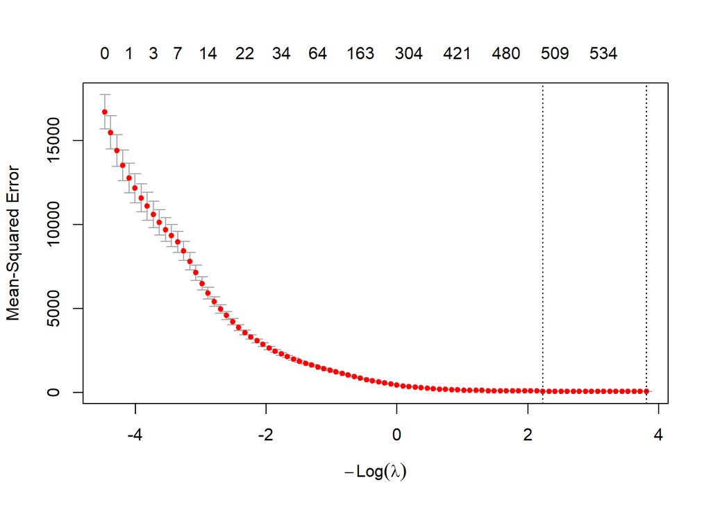

```r
plot(cv_lasso_price)
```

```r
lasso_price_best_model = glmnet(X_train_matrix, price_train, alpha = 1, lambda=lasso_price_best_lambda)
coef(lasso_price_best_model)
```

```
## 581 x 1 sparse Matrix of class "dgCMatrix"
##                                                                 s0
## (Intercept)                                              -2.83e+04
## total_population                                          6.15e-06
## pct_female                                                1.25e+00
## pct_white                                                -1.51e+00
## pct_black                                                -2.02e+00
## pct_aian                                                  .
## pct_asian                                                 7.66e+00
## pct_nhpi                                                  1.05e+01
## pct_two_or_more                                           .
## pct_hispanic                                              8.87e-02
## median_age                                                3.75e+00
## pct_under_18                                             -1.34e+00
## total_households                                          2.44e-07
## pct_married_couple                                        4.18e-01
## pct_male_householder                                     -2.97e+00
## pct_female_householder                                   -2.60e-02
## pct_unemployed                                            1.11e+00
## pct_below_poverty                                        -3.13e+00
## pct_income_10_14999                                      -1.68e+00
## pct_income_15_24999                                      -5.95e+00
## pct_income_25_34999                                      -2.96e+00
## pct_income_35_49999                                      -2.11e+00
## pct_income_50_74999                                      -3.41e+00
## pct_income_75_99999                                      -2.95e+00
## pct_income_100_149k                                       1.15e+00
## pct_income_150_199k                                       7.11e-02
## pct_income_200k_plus                                      1.28e+00
## median_household_income                                   .
## pct_high_school_plus                                      .
## pct_bachelors_plus                                        .
## total_housing_units                                      -1.69e-05
## pct_vacant_units                                          2.63e+00
## pct_owner_occupied                                       -1.76e+00
## pct_built_2020_plus                                       1.58e+00
## pct_built_2010_2019                                       1.00e-02
## pct_built_2000_2009                                       7.01e-01
## pct_built_1990_1999                                       1.59e+00
## pct_built_1980_1989                                      -7.73e-03
```

[output cut: 528 more lines]

```
## cbsa_titleWilson, NC                                     -8.82e+00
## cbsa_titleWinchester, VA-WV                               2.24e+01
## cbsa_titleWinston-Salem, NC                              -9.55e+00
## cbsa_titleWisconsin Rapids-Marshfield, WI                -4.40e+01
## cbsa_titleWooster, OH                                     1.61e+01
## cbsa_titleWorcester, MA                                   9.36e+00
## cbsa_titleYakima, WA                                      3.14e+01
## cbsa_titleYork-Hanover, PA                                8.13e+00
## cbsa_titleYoungstown-Warren, OH                           1.21e+01
## cbsa_titleYuba City, CA                                  -8.36e+01
## cbsa_titleYuma, AZ                                        1.55e+00
## cbsa_titleZanesville, OH                                 -7.27e+00
## total_listing_count                                      -2.85e-05
## pending_ratio                                             3.82e-01
## median_days_on_market                                    -2.27e-01
```

The LASSO model uses cross-validation to pick a penalty (0.0221) that balances fit and complexity. At that setting, many coefficients are shrunk exactly to zero (the “.” entries), so the model is doing built-in feature selection while keeping only the strongest signals. The remaining nonzero terms include a mix of socioeconomic variables and CBSA indicators, which suggests that a meaningful share of price differences is still place-specific even after accounting for observed market and demographic controls.

##### Median Listing Price per Square Foot Without CBSA Codes

```r
cv_lasso_price_no_cbsa = cv.glmnet(X_train_no_cbsa_matrix, price_train, alpha = 1)

lasso_price_no_cbsa_best_lambda = cv_lasso_price_no_cbsa$lambda.min
lasso_price_no_cbsa_best_lambda
```

```
## [1] 0.00871
```

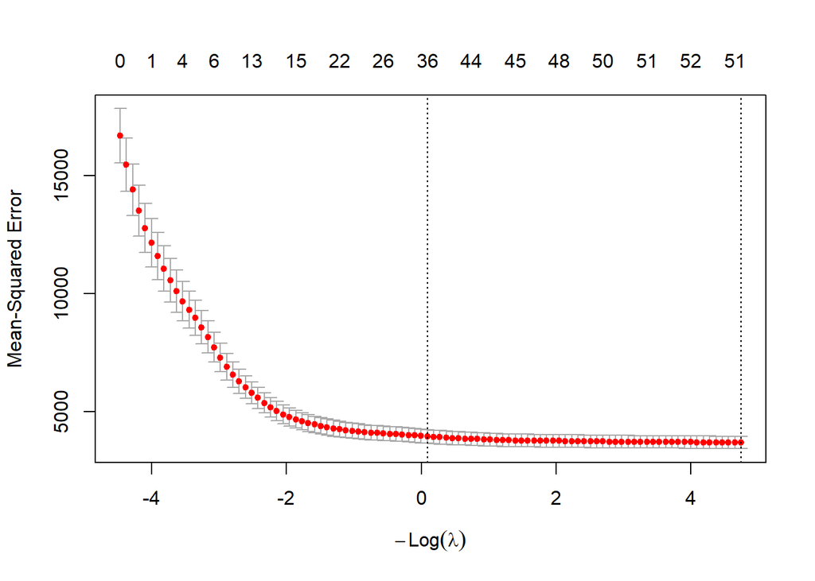

```r
plot(cv_lasso_price_no_cbsa)
```

```r
lasso_price_no_cbsa_best_model = glmnet(X_train_no_cbsa_matrix, price_train, alpha = 1, lambda=lasso_price_no_cbsa_best_lambda)
coef(lasso_price_no_cbsa_best_model)
```

```
## 53 x 1 sparse Matrix of class "dgCMatrix"
##                                       s0
## (Intercept)             8558.64296086404
## total_population           0.00005748036
## pct_female                 2.64249225410
## pct_white                 -3.45508439291
## pct_black                 -3.97377644423
## pct_aian                  -3.56351837921
## pct_asian                 -2.76107999747
## pct_nhpi                  22.12693667884
## pct_two_or_more           -4.04460426753
## pct_hispanic               0.43562573520
## median_age                 2.39759589186
## pct_under_18              -4.37355011855
## total_households          -0.00043711653
## pct_married_couple        -4.33307565435
## pct_male_householder      -8.59148693367
## pct_female_householder    -3.63143394876
## pct_unemployed            -7.62822856157
## pct_below_poverty         -0.97023858697
## pct_income_10_14999        1.03952918534
## pct_income_15_24999        6.29423663715
## pct_income_25_34999        3.20800639128
## pct_income_35_49999        4.32468728962
## pct_income_50_74999        3.45166318929
## pct_income_75_99999        0.00137717272
## pct_income_100_149k        4.64515410501
## pct_income_150_199k        1.82586284515
## pct_income_200k_plus       8.03131887836
## median_household_income    0.00417472933
## pct_high_school_plus      -0.15404493456
## pct_bachelors_plus        -0.67637316136
## total_housing_units        0.00028596733
## pct_vacant_units           4.36141351837
## pct_owner_occupied        -3.98585115960
## pct_built_2020_plus        1.49258264384
## pct_built_2010_2019        0.58493218356
## pct_built_2000_2009        1.74238104171
## pct_built_1990_1999        5.34408170918
## pct_built_1980_1989        0.04760619616
## pct_built_1970_1979        4.42778994983
## pct_built_1960_1969        3.28417415527
## pct_built_1950_1959        1.44522674786
## pct_built_1940_1949        1.06215683361
## pct_1_bed                 -3.02376699786
## pct_2_bed                 -5.81814692770
## pct_3_bed                 -5.62966127322
## pct_4_bed                -10.03801360160
## pct_5plus_bed             -4.75030766219
## area_typeMetro           -19.11903103655
## area_typeMicro             0.00000000117
## month_date_yyyymm         -0.03785014164
## total_listing_count       -0.00427729735
## pending_ratio            -13.12349573252
## median_days_on_market      0.32987981969
```

This version of the LASSO excludes CBSA fixed effects and therefore focuses only on observable housing and demographic characteristics. The cross-validated penalty (0.0087) retains a relatively broad set of predictors, indicating that many structural features still contribute meaningfully to price variation even without place-specific controls. Compared to the CBSA-inclusive model, the coefficients are more interpretable as general market relationships, and the negative coefficient on total listing count aligns with the expectation that higher supply is associated with lower prices once broader conditions are accounted for.

#### Log Median Listing Price per Square Foot

```r
cv_lasso_log_price = cv.glmnet(X_train_matrix, log_price_train, alpha = 1)

lasso_log_price_best_lambda = cv_lasso_log_price$lambda.min
lasso_log_price_best_lambda
```

```
## [1] 0.0000929
```

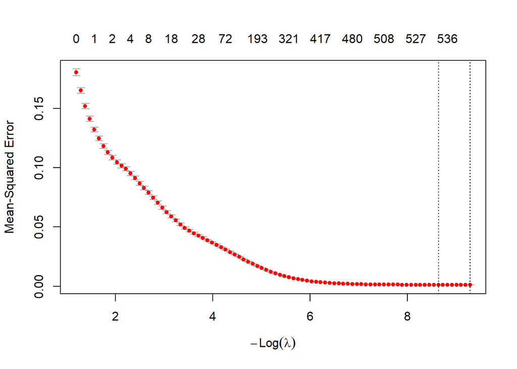

```r
plot(cv_lasso_log_price)
```

```r
lasso_log_price_best_model = glmnet(X_train_matrix, log_price_train, alpha = 1, lambda=lasso_log_price_best_lambda)
coef(lasso_log_price_best_model)
```

```
## 581 x 1 sparse Matrix of class "dgCMatrix"
##                                                                 s0
## (Intercept)                                              -4.25e+02
## total_population                                          .
## pct_female                                                1.82e-03
## pct_white                                                -4.52e-03
## pct_black                                                -7.74e-03
## pct_aian                                                  2.55e-04
## pct_asian                                                 7.46e-03
## pct_nhpi                                                  1.01e-02
## pct_two_or_more                                           .
## pct_hispanic                                              1.14e-03
## median_age                                                1.40e-02
## pct_under_18                                             -4.18e-04
## total_households                                          2.79e-09
## pct_married_couple                                        .
## pct_male_householder                                     -1.63e-02
## pct_female_householder                                   -5.09e-03
## pct_unemployed                                            2.79e-02
## pct_below_poverty                                        -1.48e-02
## pct_income_10_14999                                      -4.08e-02
## pct_income_15_24999                                      -1.18e-02
## pct_income_25_34999                                      -1.39e-02
## pct_income_35_49999                                      -1.61e-02
## pct_income_50_74999                                      -2.29e-02
## pct_income_75_99999                                      -2.08e-02
## pct_income_100_149k                                      -3.23e-04
## pct_income_150_199k                                       1.02e-03
## pct_income_200k_plus                                      1.11e-02
## median_household_income                                   .
## pct_high_school_plus                                      .
## pct_bachelors_plus                                        .
## total_housing_units                                       .
## pct_vacant_units                                          1.25e-02
## pct_owner_occupied                                       -9.68e-03
## pct_built_2020_plus                                       1.26e-02
## pct_built_2010_2019                                       .
## pct_built_2000_2009                                       2.40e-04
## pct_built_1990_1999                                       1.02e-02
## pct_built_1980_1989                                       2.56e-03
```

[output cut: 528 more lines]

```
## cbsa_titleWilson, NC                                      5.41e-03
## cbsa_titleWinchester, VA-WV                              -5.27e-04
## cbsa_titleWinston-Salem, NC                               2.36e-02
## cbsa_titleWisconsin Rapids-Marshfield, WI                -1.17e-01
## cbsa_titleWooster, OH                                     1.02e-01
## cbsa_titleWorcester, MA                                   6.97e-02
## cbsa_titleYakima, WA                                      1.43e-01
## cbsa_titleYork-Hanover, PA                               -9.96e-03
## cbsa_titleYoungstown-Warren, OH                           1.32e-03
## cbsa_titleYuba City, CA                                  -1.88e-02
## cbsa_titleYuma, AZ                                        1.57e-02
## cbsa_titleZanesville, OH                                 -8.62e-02
## total_listing_count                                      -4.60e-07
## pending_ratio                                             2.17e-02
## median_days_on_market                                    -9.51e-04
```

For the log price LASSO, cross-validation selects a much smaller penalty (0.000093), which means the model shrinks less aggressively and keeps many CBSA indicators in play. Even so, several broad market factors still show up with non-zero coefficients, and total listing count remains slightly negative, consistent with a small downward association between supply and prices once other features are considered. Overall, this suggests the log scale is easier to fit with fine-grained location effects while still preserving a handful of general relationships outside of CBSA alone.

##### Log Median Listing Price per Square Foot Without CBSA Codes

```r
cv_lasso_log_price_no_cbsa = cv.glmnet(X_train_no_cbsa_matrix, log_price_train, alpha = 1)

lasso_log_price_no_cbsa_best_lambda = cv_lasso_log_price$lambda.min
lasso_log_price_no_cbsa_best_lambda
```

```
## [1] 0.0000929
```

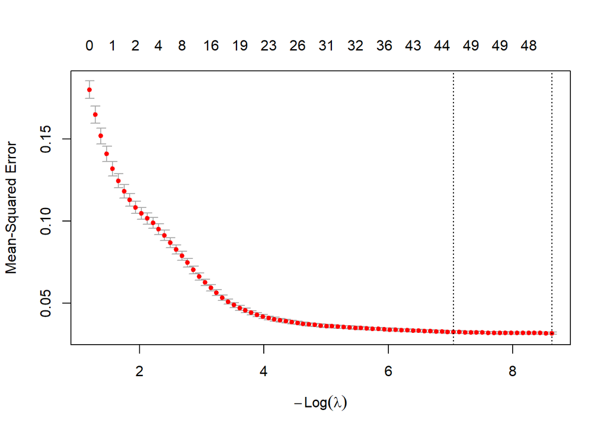

```r
plot(cv_lasso_log_price_no_cbsa)
```

```r
lasso_log_price_no_cbsa_best_model = glmnet(X_train_no_cbsa_matrix, log_price_train, alpha = 1, lambda=lasso_log_price_no_cbsa_best_lambda)
coef(lasso_log_price_no_cbsa_best_model)
```

```
## 53 x 1 sparse Matrix of class "dgCMatrix"
##                                s0
## (Intercept)             -1.62e+02
## total_population         1.67e-08
## pct_female               2.23e-02
## pct_white               -1.75e-02
## pct_black               -2.13e-02
## pct_aian                -1.43e-02
## pct_asian               -1.82e-02
## pct_nhpi                 2.14e-02
## pct_two_or_more         -1.46e-02
## pct_hispanic            -1.31e-03
## median_age               8.33e-03
## pct_under_18            -2.29e-02
## total_households         .
## pct_married_couple      -1.33e-02
## pct_male_householder    -2.82e-02
## pct_female_householder  -1.46e-02
## pct_unemployed          -4.11e-03
## pct_below_poverty       -7.15e-03
## pct_income_10_14999      1.37e-02
## pct_income_15_24999      1.55e-02
## pct_income_25_34999      1.42e-02
## pct_income_35_49999      1.83e-02
## pct_income_50_74999      1.68e-02
## pct_income_75_99999      1.94e-02
## pct_income_100_149k      3.41e-02
## pct_income_150_199k      3.99e-02
## pct_income_200k_plus     5.01e-02
## median_household_income  8.58e-08
## pct_high_school_plus    -3.78e-04
## pct_bachelors_plus      -1.19e-03
## total_housing_units      3.34e-08
## pct_vacant_units         1.10e-02
## pct_owner_occupied      -1.36e-02
## pct_built_2020_plus      1.70e-02
## pct_built_2010_2019      2.01e-03
## pct_built_2000_2009      8.14e-03
## pct_built_1990_1999      1.94e-02
## pct_built_1980_1989      5.71e-03
## pct_built_1970_1979      1.65e-02
## pct_built_1960_1969      5.18e-03
## pct_built_1950_1959      5.10e-03
## pct_built_1940_1949      6.84e-03
## pct_1_bed               -1.05e-02
## pct_2_bed               -1.40e-02
## pct_3_bed               -1.66e-02
## pct_4_bed               -2.65e-02
## pct_5plus_bed           -1.26e-02
## area_typeMetro          -6.41e-02
## area_typeMicro           4.82e-13
## month_date_yyyymm        8.33e-04
## total_listing_count     -1.18e-05
## pending_ratio           -5.43e-02
## median_days_on_market    2.19e-04
```

### Regression Tree

We also estimated an expanded regression tree to capture nonlinear relationships between median price per square foot and socioeconomic and housing characteristics. The resulting tree makes one point very clear: income dominates every other predictor. The initial split occurs at median household income, separating a small group of high-income markets with substantially higher prices from the broader set of lower-income areas. Within the lower-income group, the model again splits on income, showing that income consistently outweighs other demographic factors in explaining price differences. Only after these income thresholds are established do additional variables add nuance. Overall, the regression tree suggests that price per square foot is primarily structured by income levels, with demographic and housing characteristics playing a secondary role.

```r
## ---- RT_simple ----
options(scipen = 999)   # turn off scientific notation

# # Keep only interpretable economic drivers
# inventory_model_simple <- full_dataset_clean %>%
#   select(
#     median_listing_price_per_square_foot,
#     total_listing_count,
#     pending_ratio,
#     median_days_on_market
#   )
#
# # Fit a simple, readable regression tree
# reg_tree_simple <- rpart(
#   median_listing_price_per_square_foot ~
#     total_listing_count + pending_ratio + median_days_on_market,
#   data = inventory_model_simple,
#   method = "anova",
#   control = rpart.control(maxdepth = 3, minbucket = 200)
# )
#
# # Plot the tree
# rpart.plot(
#   reg_tree_simple,
#   type = 2,
#   extra = 101,
#   under = TRUE,
#   fallen.leaves = TRUE,
#   roundint = TRUE,
#   main = "Regression Tree: Price per Sq.Ft"
# )

# Basic check: supply distribution
summary(full_dataset_clean$total_listing_count)
```

```
##    Min. 1st Qu.  Median    Mean 3rd Qu.    Max.
##      40     335     626    2090    1633   52936
```

```r
#stephs expanded regression tree (median)
tree_data_med <- train %>%
  select(-log_median_price_sqft,
         -cbsa_title) %>%
  na.omit()

set.seed(42)
reg_tree_exp_med <- rpart(median_listing_price_per_square_foot ~ .,
                      data = tree_data_med,
                      method = "anova",
                      control = rpart.control(minbucket = 200))

best_cp_med <- reg_tree_exp_med$cptable[which.min(reg_tree_exp_med$cptable[,"xerror"]), "CP"]
best_cp_med
```

```
## [1] 0.01
```

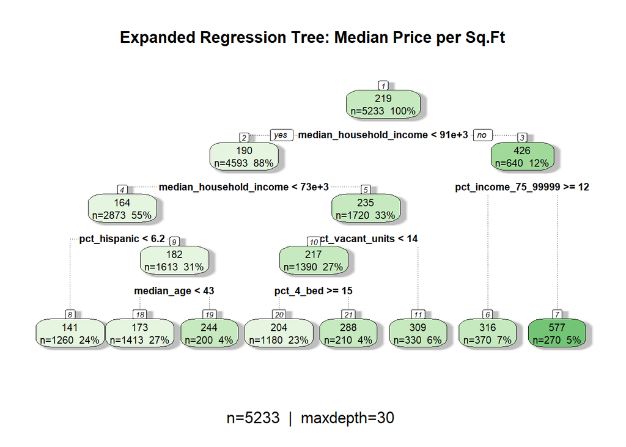

```r
pruned_tree_data_med <- prune(reg_tree_exp_med,
                              cp = best_cp_med)

options(repr.plot.width = 28,
        repr.plot.height = 14)

fancyRpartPlot(reg_tree_exp_med,
               main = "Expanded Regression Tree: Median Price per Sq.Ft",
               sub = paste0("n=", nrow(tree_data_med), "  |  maxdepth=", reg_tree_exp_med$control$maxdepth),
               cex = 1.4,
               tweak = 0.5)
```

### Random Forest Regression

The plot reports Random Forest variable importance (MSE increase), indicating which features the model relies on most for prediction.

Percent under 18 (pct_under_18) and percent vacant units (pct_vacant_units) are the two most important predictors, suggesting that demographic structure and housing availability prior to a sale include substantial information to predict the price.

The prominence of these variables indicates that the model primarily reflects sociological factors and pre-sale occupancy conditions, rather than short-term transactional or pricing signals.

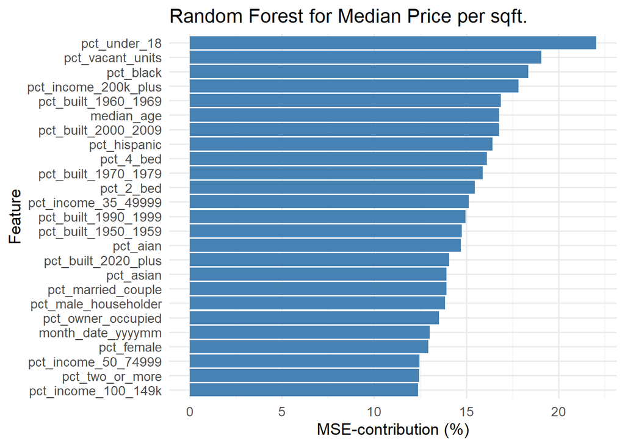

```r
set.seed(42)
rf_data_med <- train %>%
  mutate(across(where(is.character), as.factor)) %>%
  select(-log_median_price_sqft,-cbsa_title ) %>% #log(price) is basically price. ; cbsa can't be used anyway
  na.omit()                   # Can not handle categorical predictors with more than 53 categories.

rf_exp_med <- randomForest(
  median_listing_price_per_square_foot ~ .,
  data = rf_data_med,
  ntree = 500,
  mtry = floor(sqrt(ncol(rf_data_med) - 1)),
  nodesize = 15,
  importance = TRUE,
  na.action = na.omit
)
imp <- randomForest::importance(rf_exp_med)
imp_df <- data.frame(
  Feature = rownames(imp),
  Importance = imp[, "%IncMSE"]
)

imp_df %>%
  top_n(25, Importance) %>% #top 25 indicators
  ggplot(aes(x=reorder(Feature, Importance), y=Importance)) +
  geom_col(fill="steelblue") +
  coord_flip() +
  labs(title="Random Forest for Median Price per sqft.",
       x="Feature",
       y="MSE-contribution (%)") +
  theme_minimal(base_size = 13)
```

#### Random Forest with Log

[figure not shown]

```r
set.seed(42)
rf_data_log <- train %>%
  select(-median_listing_price_per_square_foot,-cbsa_title ) #log(price) is basically price. ; cbsa can't be used anyway                   # Can not handle categorical predictors with more than 53 categories.

rf_exp_log <- randomForest(
  log_median_price_sqft ~ .,
  data = rf_data_log,
  ntree = 500,
  mtry = floor(sqrt(ncol(rf_data_log) - 1)),
  nodesize = 15,
  importance = TRUE,
  na.action = na.omit
)
imp_log <- randomForest::importance(rf_exp_log)
imp_log_df <- data.frame(
  Feature = rownames(imp_log),
  Importance = imp[, "%IncMSE"]
)

imp_log_df %>%
  top_n(25, Importance) %>% #top 25 indicators
  ggplot(aes(x=reorder(Feature, Importance), y=Importance)) +
  geom_col(fill="steelblue") +
  coord_flip() +
  labs(title="Random Forest for log(Median Price) per sqft.",
       x="Feature",
       y="MSE-contribution (%)") +
  theme_minimal(base_size = 13)
```

## Model Evaluation

```r
# models = list(reg_model_by_1, reg_model_by_all, lasso_price_best_model, lasso_price_no_cbsa_best_model, reg_tree_simple, reg_tree_exp_med, rf_exp_med)
#
# log_models = list(reg_model_log_by_1, reg_model_log_by_all, lasso_log_price_best_model, lasso_log_price_no_cbsa_best_model)

reg_model_by_1_pred = predict(reg_model_by_1, newdata = test)
reg_model_by_all_pred = predict(reg_model_by_all, newdata = test)
lasso_price_best_model_pred = predict(lasso_price_best_model, newx=X_test_matrix)
lasso_price_no_cbsa_best_model_pred = predict(lasso_price_no_cbsa_best_model, newx=X_test_no_cbsa_matrix)
#reg_tree_simple_pred = predict(reg_tree_simple, newdata = test)
reg_tree_exp_med_pred = predict(reg_tree_exp_med, newdata = test)
rf_exp_med_pred = predict(rf_exp_med, newdata = test)
reg_model_log_by_1_pred = predict(reg_model_log_by_1, newdata = test)
reg_model_log_by_all_pred = predict(reg_model_log_by_all, newdata = test)
lasso_log_price_best_model_pred = predict(lasso_log_price_best_model, newx=X_test_matrix)
lasso_log_price_no_cbsa_best_model_pred = predict(lasso_log_price_no_cbsa_best_model, newx=X_test_no_cbsa_matrix)
rf_exp_log_pred = predict(rf_exp_log, newdata = test)

reg_model_by_1_rmse = rmse(actual = price_test, predicted = reg_model_by_1_pred)
reg_model_by_all_rmse = rmse(actual = price_test, predicted = reg_model_by_all_pred)
lasso_price_best_model_rmse = rmse(actual = price_test, predicted = lasso_price_best_model_pred)
lasso_price_no_cbsa_best_model_rmse = rmse(actual = price_test, predicted = lasso_price_no_cbsa_best_model_pred)
#reg_tree_simple_rmse = rmse(actual = price_test, predicted = reg_tree_simple_pred)
reg_tree_exp_med_rmse = rmse(actual = price_test, predicted = reg_tree_exp_med_pred)
rf_exp_med_rmse = rmse(actual = price_test, predicted = rf_exp_med_pred)
reg_model_log_by_1_rmse = rmse(actual = price_test, predicted = exp(reg_model_log_by_1_pred))
reg_model_log_by_all_rmse = rmse(actual = price_test, predicted = exp(reg_model_log_by_all_pred))
lasso_log_price_best_model_rmse = rmse(actual = price_test, predicted = exp(lasso_log_price_best_model_pred))
lasso_log_price_no_cbsa_best_model_rmse = rmse(actual = price_test, predicted = exp(lasso_log_price_no_cbsa_best_model_pred))
rf_exp_log_rmse = rmse(actual = price_test, predicted = exp(rf_exp_log_pred))


rmse_df = data.frame(Model = c("reg_model_by_1", "reg_model_by_all", "lasso_price_best_model", "lasso_price_no_cbsa_best_model",
                               #"reg_tree_simple",
                               "reg_tree_exp_med", "rf_exp_med", "reg_model_log_by_1", "reg_model_log_by_all", "lasso_log_price_best_model", "lasso_log_price_no_cbsa_best_model", "rf_exp_log"),
                     RMSE = c(reg_model_by_1_rmse, reg_model_by_all_rmse, lasso_price_best_model_rmse, lasso_price_no_cbsa_best_model_rmse,
                              #reg_tree_simple_rmse,
                              reg_tree_exp_med_rmse, rf_exp_med_rmse, reg_model_log_by_1_rmse, reg_model_log_by_all_rmse, lasso_log_price_best_model_rmse, lasso_log_price_no_cbsa_best_model_rmse, rf_exp_log_rmse)
                     )
  # reg_model_by_1 = reg_model_by_1_rmse,
  #                    reg_model_by_all = reg_model_by_all_rmse,
  #                    lasso_price_best_model = lasso_price_best_model_rmse,
  #                    lasso_price_no_cbsa_best_model = lasso_price_no_cbsa_best_model_rmse,
  #                    reg_tree_simple = reg_tree_simple_rmse,
  #                    reg_tree_exp_med = reg_tree_exp_med_rmse,
  #                    rf_exp_med = rf_exp_med_rmse,
  #                    reg_model_log_by_1 = reg_model_log_by_1_rmse,
  #                    reg_model_log_by_all = reg_model_log_by_all_rmse,
  #                    lasso_log_price_best_model = lasso_log_price_best_model_rmse,
  #                    lasso_log_price_no_cbsa_best_model = lasso_log_price_no_cbsa_best_model_rmse
  #                    )

xkabledply(rmse_df)
```

Model: Model ~ RMSE

| Model | RMSE |
| --- | --- |
| reg_model_by_1 | 128.8 |
| reg_model_by_all | 60.1 |
| lasso_price_best_model | 10.6 |
| lasso_price_no_cbsa_best_model | 60.2 |
| reg_tree_exp_med | 82.7 |
| rf_exp_med | 10.7 |
| reg_model_log_by_1 | 131.0 |
| reg_model_log_by_all | 55.0 |
| lasso_log_price_best_model | 10.4 |
| lasso_log_price_no_cbsa_best_model | 55.3 |
| rf_exp_log | 10.8 |

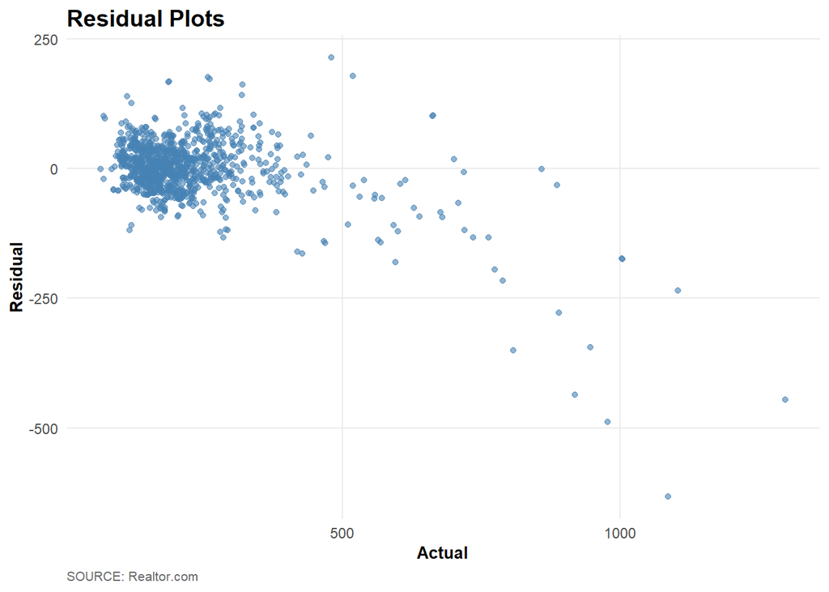

```r
residual_graphs <- ggplot(data = data.frame(actual = price_test,
                                            residual = reg_model_by_all_pred - price_test),
                          aes(x = actual, y = residual)) +
  geom_point(alpha = 0.6, color = "steelblue") +
  labs(title = "Residual Plots",
       # subtitle = "Log transformation reduces skew and reveals variation across listings",
       x = "Actual",
       y = "Residual",
       caption = "SOURCE: Realtor.com") +
  # scale_y_continuous(labels = function(x) dollar(exp(x), accuracy = 1)) +
  theme_minimal(base_size = 11) +
  theme(plot.title    = element_text(face="bold", size=14, margin=ggplot2::margin(b=3)),
        plot.subtitle = element_text(size=10, color="gray25", margin=ggplot2::margin(b=8)),
        plot.caption  = element_text(size=8, color="gray40", hjust=0),
        axis.title    = element_text(size=10, face="bold"),
        axis.text     = element_text(size=9),
        panel.grid.minor = element_blank(),
        panel.background  = element_blank(),
        plot.background   = element_blank())

residual_graphs
```

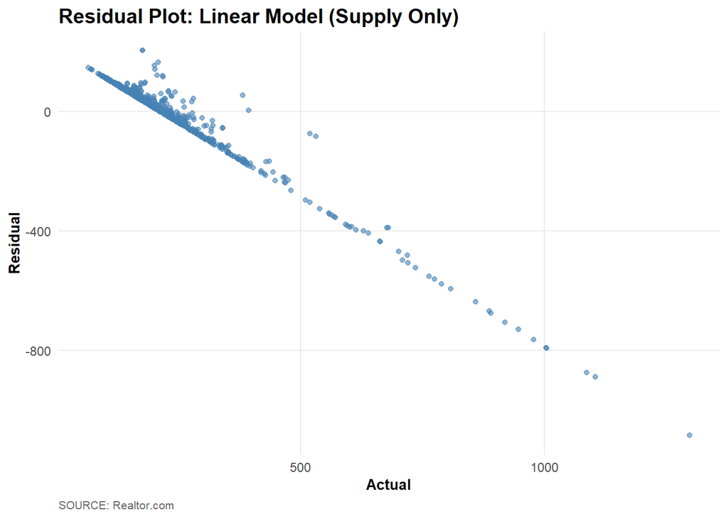

```r
residual_reg_by_1 <- ggplot(data = data.frame(actual = price_test,
                                              residual = reg_model_by_1_pred - price_test),
                            aes(x = actual,
                                y = residual)) +
  geom_point(alpha = 0.6,
             color = "steelblue") +
  labs(title = "Residual Plot: Linear Model (Supply Only)",
       x = "Actual",
       y = "Residual",
       caption = "SOURCE: Realtor.com") +
  theme_minimal(base_size = 11) +
  theme(plot.title    = element_text(face="bold",
                                     size=14,
                                     margin=ggplot2::margin(b=3)),
        plot.subtitle = element_text(size=10,
                                     color="gray25",
                                     margin=ggplot2::margin(b=8)),
        plot.caption  = element_text(size=8,
                                     color="gray40",
                                     hjust=0),
        axis.title    = element_text(size=10,
                                     face="bold"),
        axis.text     = element_text(size=9),
        panel.grid.minor = element_blank(),
        panel.background  = element_blank(),
        plot.background   = element_blank())

residual_reg_by_1
```

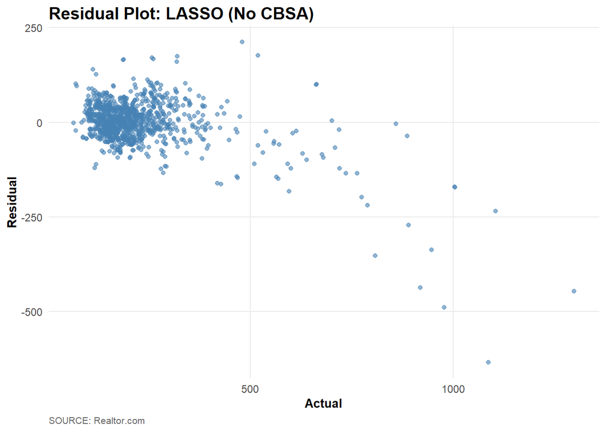

```r
residual_lasso <- ggplot(data = data.frame(actual = price_test,
                                           residual = as.numeric(lasso_price_no_cbsa_best_model_pred) - price_test),
                         aes(x = actual, y = residual)) +
  geom_point(alpha = 0.6,
             color = "steelblue") +
  labs(title = "Residual Plot: LASSO (No CBSA)",
       x = "Actual",
       y = "Residual",
       caption = "SOURCE: Realtor.com") +
  theme_minimal(base_size = 11) +
  theme(plot.title    = element_text(face="bold",
                                     size=14,
                                     margin=ggplot2::margin(b=3)),
        plot.subtitle = element_text(size=10,
                                     color="gray25",
                                     margin=ggplot2::margin(b=8)),
        plot.caption  = element_text(size=8,
                                     color="gray40",
                                     hjust=0),
        axis.title    = element_text(size=10,
                                     face="bold"),
        axis.text     = element_text(size=9),
        panel.grid.minor = element_blank(),
        panel.background  = element_blank(),
        plot.background   = element_blank())

residual_lasso
```

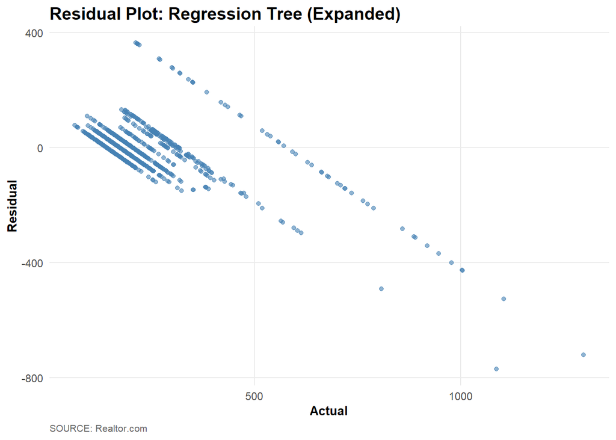

```r
residual_tree <- ggplot(data = data.frame(actual = price_test,
                                          residual = reg_tree_exp_med_pred - price_test),
                        aes(x = actual, y = residual)) +
  geom_point(alpha = 0.6,
             color = "steelblue") +
  labs(title = "Residual Plot: Regression Tree (Expanded)",
       x = "Actual",
       y = "Residual",
       caption = "SOURCE: Realtor.com") +
  theme_minimal(base_size = 11) +
  theme(plot.title    = element_text(face="bold",
                                     size=14,
                                     margin=ggplot2::margin(b=3)),
        plot.subtitle = element_text(size=10,
                                     color="gray25",
                                     margin=ggplot2::margin(b=8)),
        plot.caption  = element_text(size=8,
                                     color="gray40",
                                     hjust=0),
        axis.title    = element_text(size=10,
                                     face="bold"),
        axis.text     = element_text(size=9),
        panel.grid.minor = element_blank(),
        panel.background  = element_blank(),
        plot.background   = element_blank())

residual_tree
```

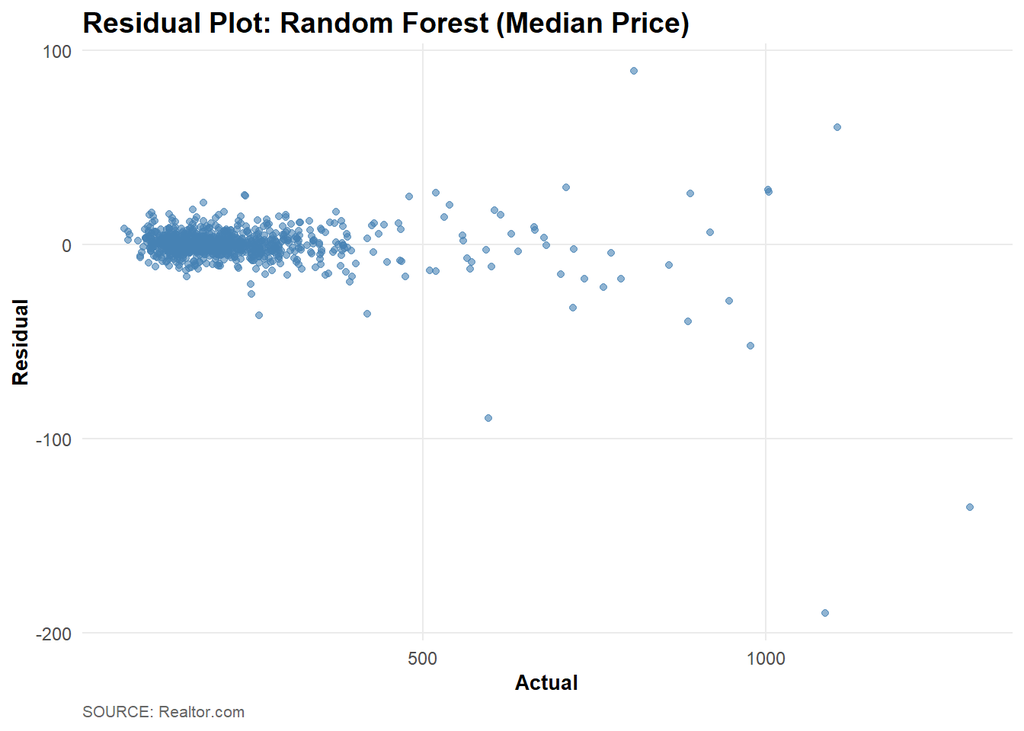

```r
residual_rf <- ggplot(data = data.frame(actual = price_test,
                                        residual = rf_exp_med_pred - price_test),
                      aes(x = actual, y = residual)) +
  geom_point(alpha = 0.6,
             color = "steelblue") +
  labs(title = "Residual Plot: Random Forest (Median Price)",
       x = "Actual",
       y = "Residual",
       caption = "SOURCE: Realtor.com") +
  theme_minimal(base_size = 11) +
  theme(plot.title    = element_text(face="bold",
                                     size=14,
                                     margin=ggplot2::margin(b=3)),
        plot.subtitle = element_text(size=10,
                                     color="gray25",
                                     margin=ggplot2::margin(b=8)),
        plot.caption  = element_text(size=8,
                                     color="gray40",
                                     hjust=0),
        axis.title    = element_text(size=10,
                                     face="bold"),
        axis.text     = element_text(size=9),
        panel.grid.minor = element_blank(),
        panel.background  = element_blank(),
        plot.background   = element_blank())

residual_rf
```

## Conclusion

### Further Applications

For further applications, the modeling approach can be extended beyond Random Forest estimation to explore feature selection and model comparison. Feature engineering using Random Forest indicators can be performed by selecting the most important variables identified by the Random Forest and reducing dimensionality to build interpretable linear models. Additionally, applying XGBoost may improve predictive accuracy relative to the Random Forest.